# MODELOS LINEARES GENERALIZADOS (EST082)

### Análise de diagnóstico

**Código**

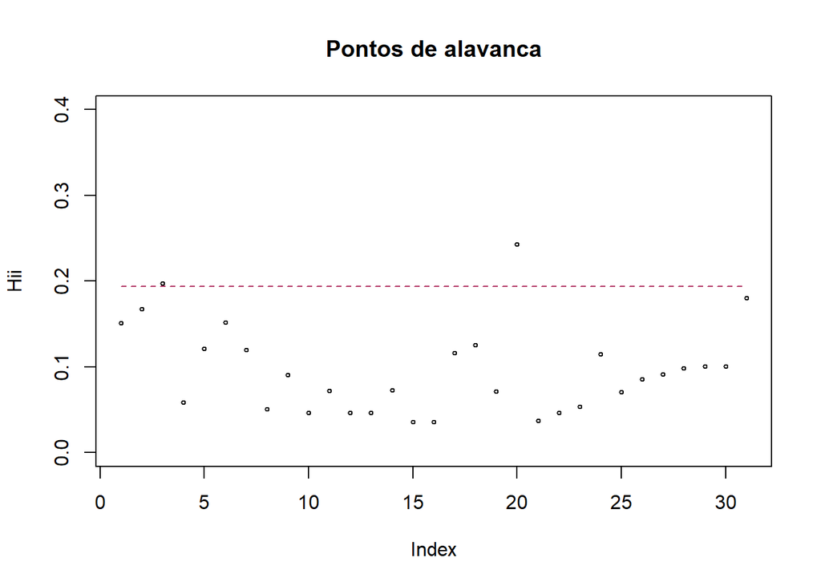

```r
influ<-influence.measures(modelo)
deffits=influ$infmat[,4] # conferir coluna
cook=influ$infmat[,6] # conferir coluna
Hii=influ$infmat[,7] # conferir coluna

n<-nrow(trees)
p<-3

corte=2*p/n
plot(Hii, pch=1, main='Pontos de alavanca', cex=0.5, ylim=c(0,0.4))
lines(1:n,corte*rep(1,n),lty=2, col='maroon')
```

**Código**

```r
#identify(Hii, n=2, tolerance = 2)
```

A observação 20 parece ser ponto de alavanca.

**Código**

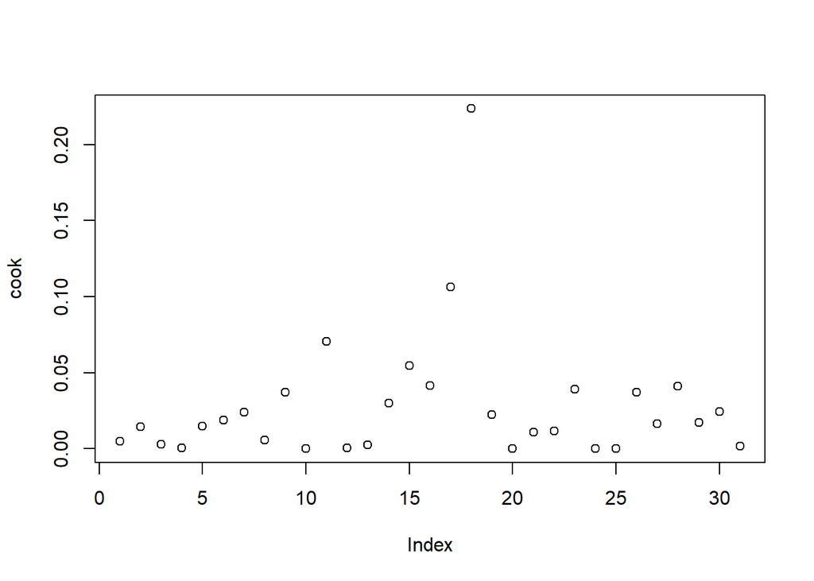

```r
corte=pf(0.5,p,n-p)
plot(cook)
lines(1:n,corte*rep(1,n), lty=2, col='maroon')
```

**Código**

```r
# identify(cook, n=2, tolerance = 1.5)
```

Nenhuma observação parece influente em termos da distância de cook.

**Código**

```r
summary(influ)
```

```
Potentially influential observations of
     lm(formula = lv ~ ld + lh) :

   dfb.1_ dfb.ld dfb.lh dffit cov.r   cook.d hat
3   0.07  -0.02  -0.06   0.09  1.38_*  0.00   0.20
20 -0.02  -0.02   0.02  -0.03  1.47_*  0.00   0.24
31  0.03  -0.04  -0.02  -0.07  1.36_*  0.00   0.18
```

As observações 3, 20 e 31 foram apontadas como influentes, elas parecem impactar na matriz de covariâncias.

### Interpretação

**Código**

```r
modelo
```

```
Call:
lm(formula = lv ~ ld + lh)

Coefficients:
(Intercept)           ld           lh
     -6.632        1.983        1.117
```

- Com o aumento de uma unidade no diâmetro espera-se que em média o volume aumento de 1.983 no volume.
- Com o aumento de uma unidade altura espera-se um aumento de 1.117.

## 24

Tbill (taxa de retorno livre de risco), retorno Microsoft, SP500 (retorno do mercado), retorno GE e retorno FORD de janeiro de 2002 a abril de 2003.

**Código**

```r
capm<-read.table("./dados/lista1/capm.txt", quote="\"")
colnames(capm) <- c("Tibill",
                    "Micros",
                    "SP500",
                    "GE",
                    "Ford")

capm<-capm |>
  mutate(exc.M=Micros-SP500,exc.GE=GE-SP500,exc.F=Ford-SP500, exc.mercado=SP500-Tibill)
```

##### Microsoft

**Código**

```r
attach(capm)
```

**Código**

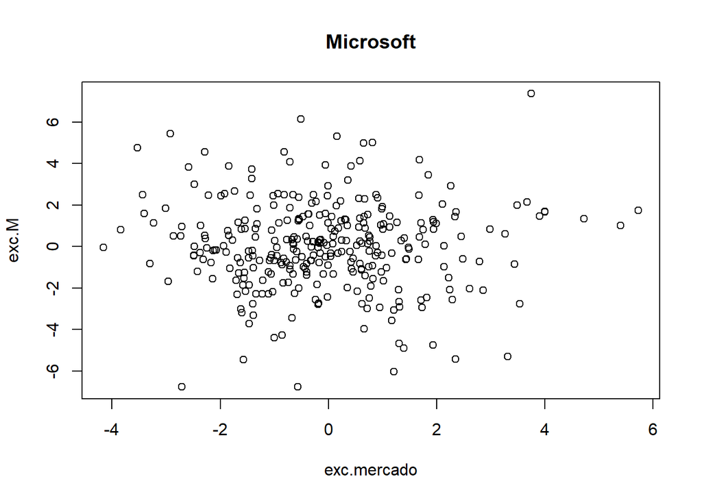

```r
plot(exc.M~exc.mercado, main="Microsoft")
```

**Código**

```r
n<-nrow(capm)
p<-2
ml1<-lm(exc.M~exc.mercado)
summary(ml1)
```

```
Call:
lm(formula = exc.M ~ exc.mercado)

Residuals:
    Min      1Q  Median      3Q     Max
-6.8511 -1.1449  0.0261  1.2206  7.4324

Coefficients:
            Estimate Std. Error t value Pr(>|t|)
(Intercept)  0.02410    0.12059   0.200    0.842
exc.mercado -0.02558    0.07406  -0.345    0.730

Residual standard error: 2.124 on 309 degrees of freedom
Multiple R-squared:  0.0003861, Adjusted R-squared:  -0.002849
F-statistic: 0.1194 on 1 and 309 DF,  p-value: 0.73
```

**Código**

```r
t.quantil<-qt(0.025,df=n-p, lower.tail = F)
LI<-(-0.02558) - 0.07406*sqrt(t.quantil)
LS<-(-0.02558) + 0.07406*sqrt(t.quantil)
```

- O parâmetro $\alpha$ não é significativo para o modelo.
- IC($\beta_1$,95%) = [-0.1294667; 0.0783067], o intervalo para beta inclui o valor zero. Dessa forma, não podemos dizer que ele é diferente de 0. O parâmetro beta também não é significativo.

**Análise dos resíduos**

**Código**

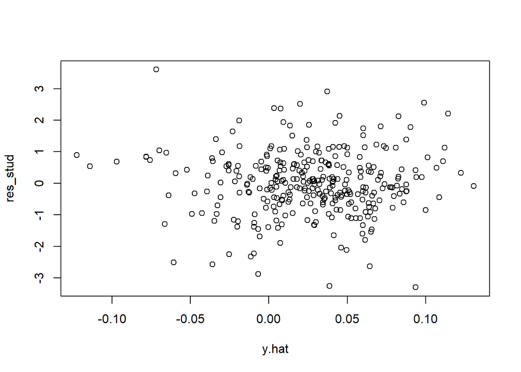

```r
y.hat<-ml1$fitted.values
res_stud<-rstudent(ml1)
plot(y.hat,res_stud)
```

**Código**

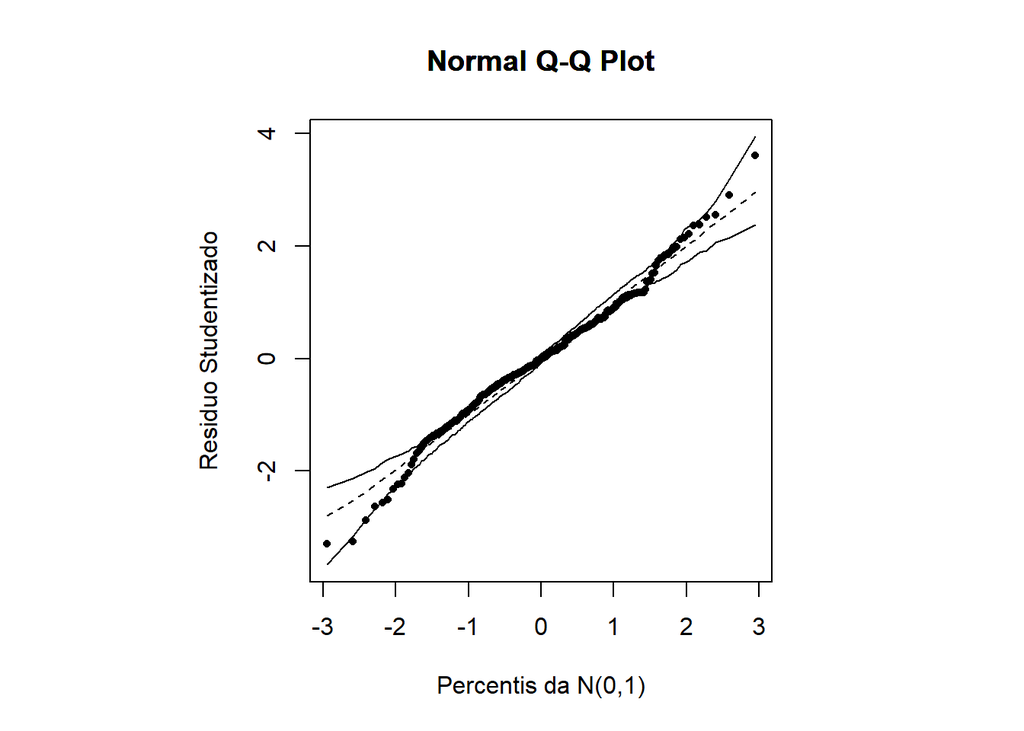

```r
envel_norm(ml1)
```

Os resíduos parecem bem comportados. Mas o modelo não foi validado, os parâmetros não são significativos.

**Diagnóstico**

Em termos práticos, o modelo não foi validado e não teríamos chegado nessa etapa.

**Código**

```r
influ<-influence.measures(ml1)
deffits=influ$infmat[,3] # conferir coluna
cook=influ$infmat[,5] # conferir coluna
Hii=influ$infmat[,6] # conferir coluna

n<-nrow(capm)
p<-2

corte=2*p/n
plot(Hii, pch=1, main='Pontos de alavanca', cex=0.5)
lines(1:n,corte*rep(1,n),lty=2, col='maroon')
```

[output not shown]

**Código**

```r
#identify(Hii, n=2, tolerance = 2)
```

Temos algumas observações como ponto de alavanca.

**Código**

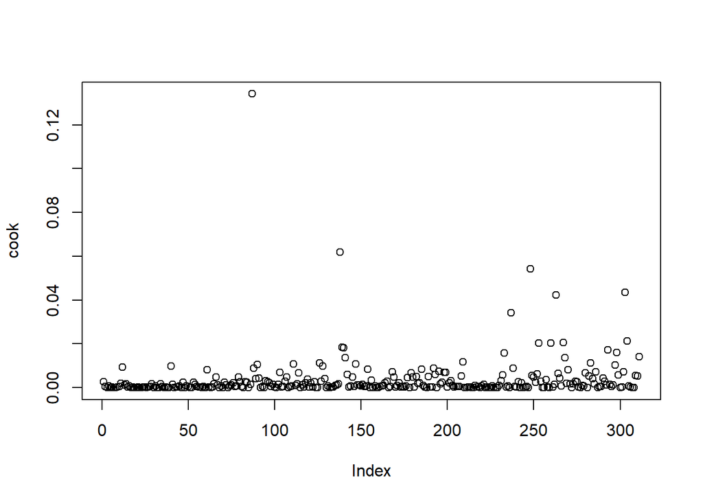

```r
corte=pf(0.5,p,n-p)
plot(cook)
lines(1:n,corte*rep(1,n), lty=2, col='maroon')
```

**Código**

```r
# identify(cook, n=2, tolerance = 1.5)
```

Nenhuma observação parece influente em termos da distância de cook.

**Código**

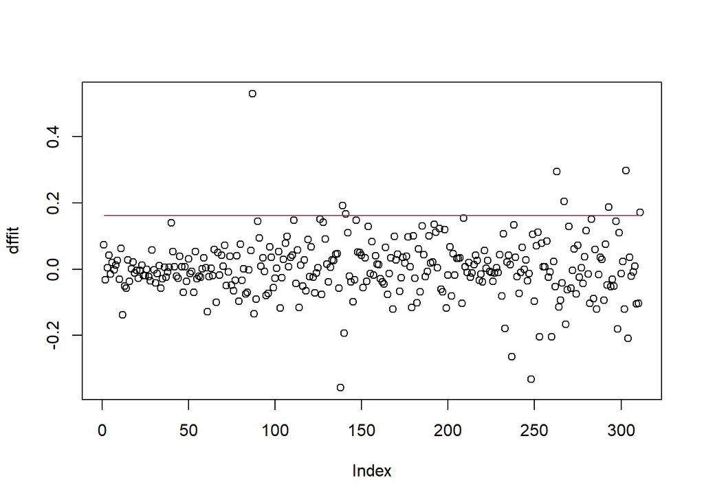

```r
dffit=influ$infmat[,3]
corte=2*sqrt(p/(n-p))
plot(dffit)
lines(1:n,corte*rep(1,n), col="maroon")
```

**Código**

```r
summary(influ)
```

```
Potentially influential observations of
     lm(formula = exc.M ~ exc.mercado) :

    dfb.1_ dfb.exc. dffit   cov.r   cook.d hat
87   0.23   0.49     0.53_*  0.95_*  0.13   0.02_*
111  0.14   0.06     0.15    0.97_*  0.01   0.00
126  0.07   0.14     0.15    1.02_*  0.01   0.02_*
129  0.04  -0.08     0.09    1.02_*  0.00   0.02
136  0.02  -0.04     0.05    1.03_*  0.00   0.02_*
137 -0.02   0.05    -0.06    1.02_*  0.00   0.02
138 -0.17   0.30    -0.36_*  0.95_*  0.06   0.01
139  0.06   0.18     0.19    1.05_*  0.02   0.04_*
140 -0.18   0.06    -0.19    0.94_*  0.02   0.00
142  0.04   0.11     0.11    1.05_*  0.01   0.04_*
148  0.03   0.05     0.05    1.02_*  0.00   0.01
```

[output cut: 20 more lines]

Algumas observações são apontadas como influentes em termos da medida Dffit.

##### Ford

**Código**

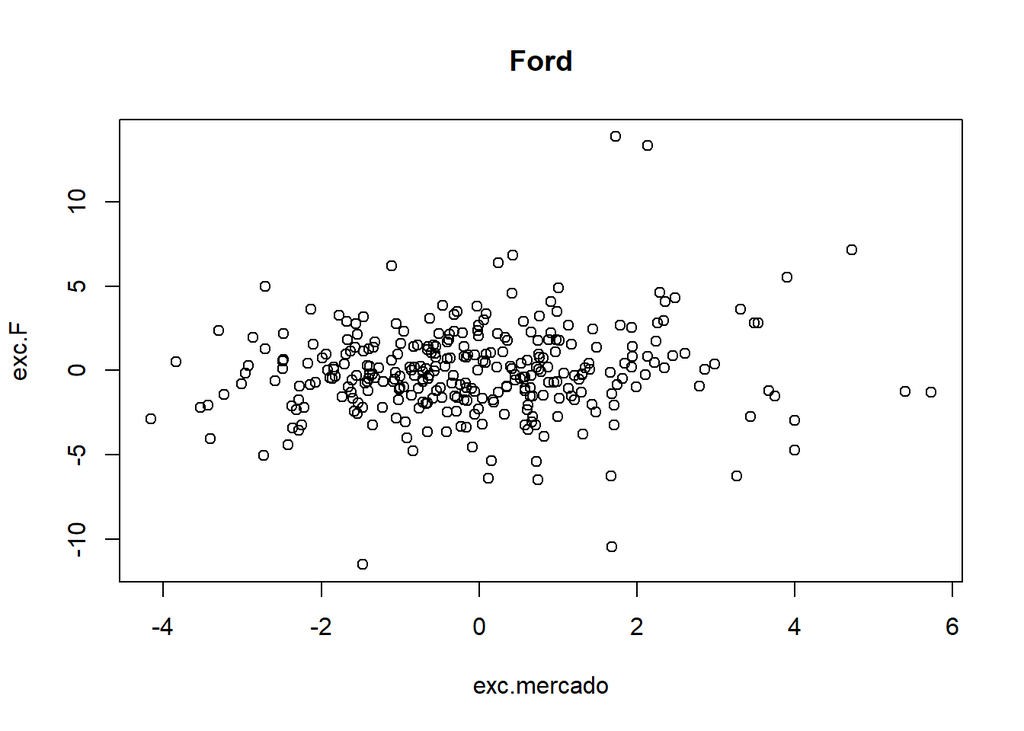

```r
plot(exc.F~exc.mercado, main="Ford")
```

**Código**

```r
ml2<-lm(exc.F~exc.mercado)
summary(ml2)
```

```
Call:
lm(formula = exc.F ~ exc.mercado)

Residuals:
     Min       1Q   Median       3Q      Max
-11.1473  -1.4730  -0.0886   1.4684  13.6096

Coefficients:
            Estimate Std. Error t value Pr(>|t|)
(Intercept) -0.07405    0.15076  -0.491   0.6236
exc.mercado  0.18828    0.09258   2.034   0.0428 *
---
Signif. codes:  0 '***' 0.001 '**' 0.01 '*' 0.05 '.' 0.1 ' ' 1

Residual standard error: 2.655 on 309 degrees of freedom
Multiple R-squared:  0.01321,   Adjusted R-squared:  0.01001
F-statistic: 4.136 on 1 and 309 DF,  p-value: 0.04284
```

**Código**

```r
t.quantil<-qt(0.025,df=n-p, lower.tail = F)
LI<-(0.18828) -  0.09258*sqrt(t.quantil)
LS<-(0.18828) +  0.09258*sqrt(t.quantil)
```

- O parâmetro $\alpha$ não é significativo para o modelo.
- IC($\beta_1$,95%) = [0.0584146; 0.3181454], temos 95% de confiabilidade de que o intervalo inclui o verdadeiro valor do parâmetro.

**Análise dos resíduos**

**Código**

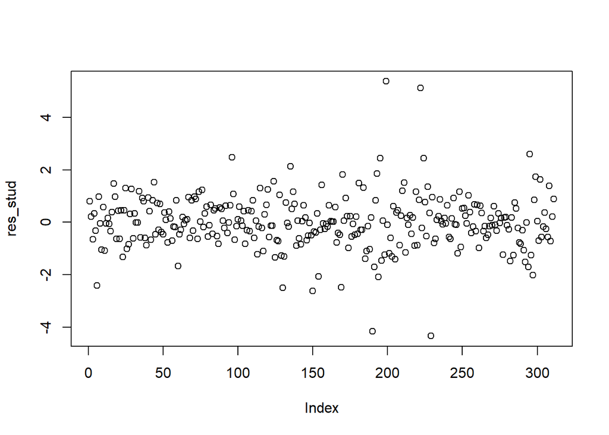

```r
y.hat<-ml2$fitted.values
res_stud<-rstudent(ml2)
plot(res_stud)
```

Temos 4 observações atípicas 190,199,222 e 229.

**Código**

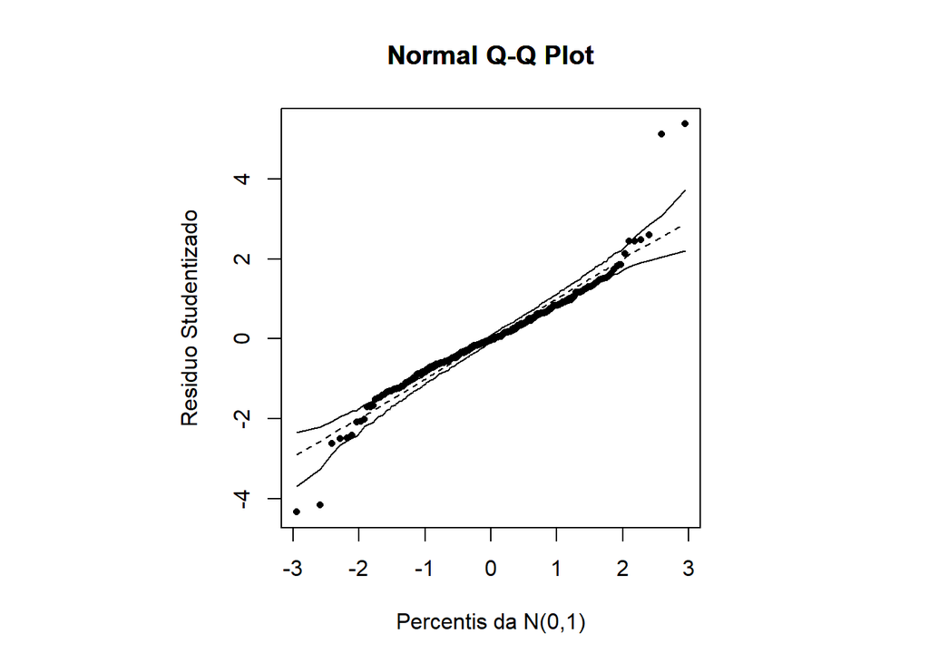

```r
envel_norm(ml2)
```

**Diagnóstico**

**Código**

```r
influ<-influence.measures(ml2)
deffits=influ$infmat[,3] # conferir coluna
cook=influ$infmat[,5] # conferir coluna
Hii=influ$infmat[,6] # conferir coluna

n<-nrow(capm)
p<-2

corte=2*p/n
plot(Hii, pch=1, main='Pontos de alavanca', cex=0.5)
lines(1:n,corte*rep(1,n),lty=2, col='maroon')
```

[output not shown]

**Código**

```r
#identify(Hii, n=2, tolerance = 2)
```

Temos algumas observações que são alavanca.

**Código**

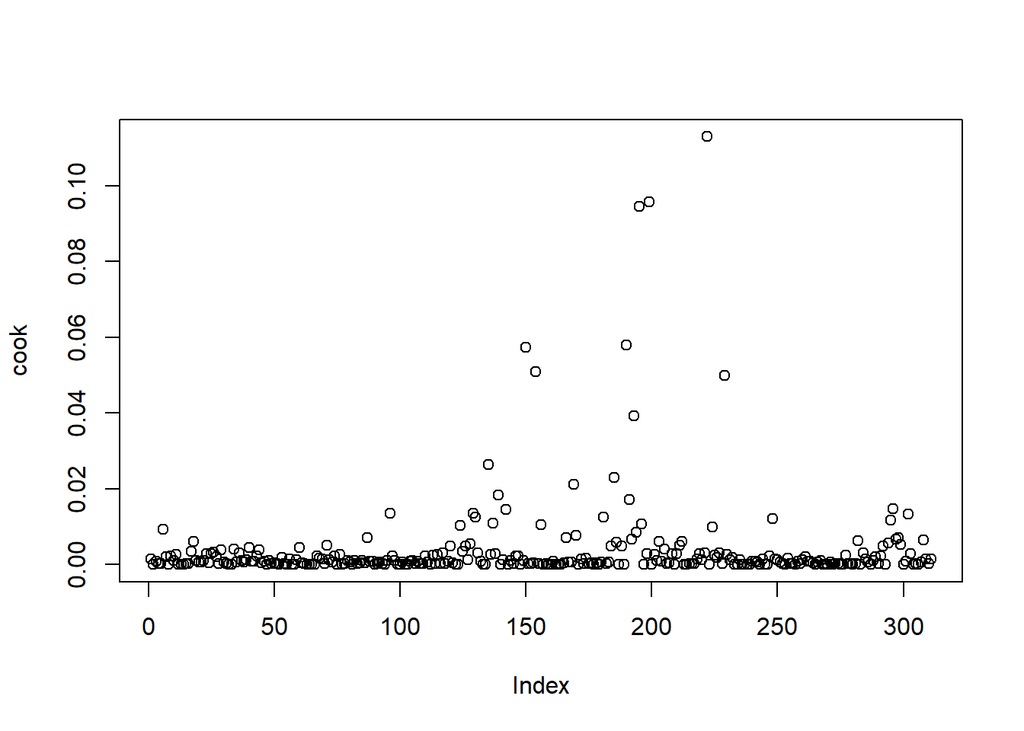

```r
corte=pf(0.5,p,n-p)
plot(cook)
lines(1:n,corte*rep(1,n), lty=2, col='maroon')
```

**Código**

```r
# identify(cook, n=2, tolerance = 1.5)
```

Nenhuma observação parece influente em termos da distância de cook.

**Código**

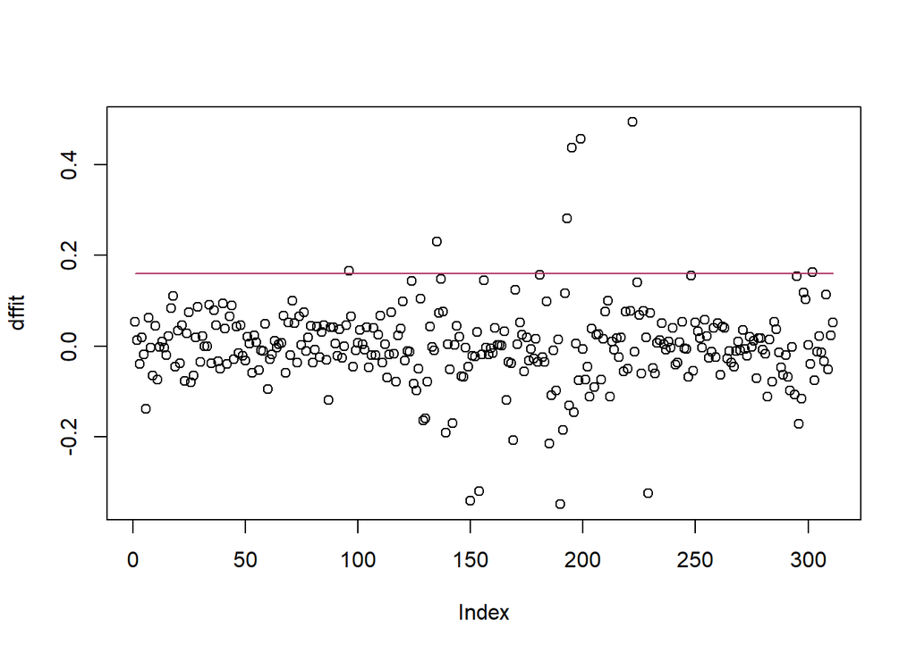

```r
dffit=influ$infmat[,3]
corte=2*sqrt(p/(n-p))
plot(dffit)
lines(1:n,corte*rep(1,n), col="maroon")
```

**Código**

```r
summary(influ)
```

```
Potentially influential observations of
     lm(formula = exc.F ~ exc.mercado) :

    dfb.1_ dfb.exc. dffit   cov.r   cook.d hat
6   -0.14  -0.02    -0.14    0.97_*  0.01   0.00
87  -0.05  -0.11    -0.12    1.02_*  0.01   0.02_*
96   0.14  -0.09     0.17    0.97_*  0.01   0.00
114 -0.01  -0.02    -0.02    1.02_*  0.00   0.01
126 -0.04  -0.09    -0.10    1.02_*  0.00   0.02_*
130 -0.15  -0.07    -0.16    0.97_*  0.01   0.00
136  0.03  -0.07     0.07    1.03_*  0.00   0.02_*
139 -0.06  -0.18    -0.19    1.05_*  0.02   0.04_*
142 -0.06  -0.16    -0.17    1.04_*  0.01   0.04_*
145  0.01  -0.02     0.02    1.02_*  0.00   0.01
147 -0.03   0.06    -0.07    1.02_*  0.00   0.02
```

[output cut: 19 more lines]

Algumas observações são apontadas como influentes em termos da medida Dffit também, inclusive as que foram apontadas como atípicas.

###### GE

**Código**

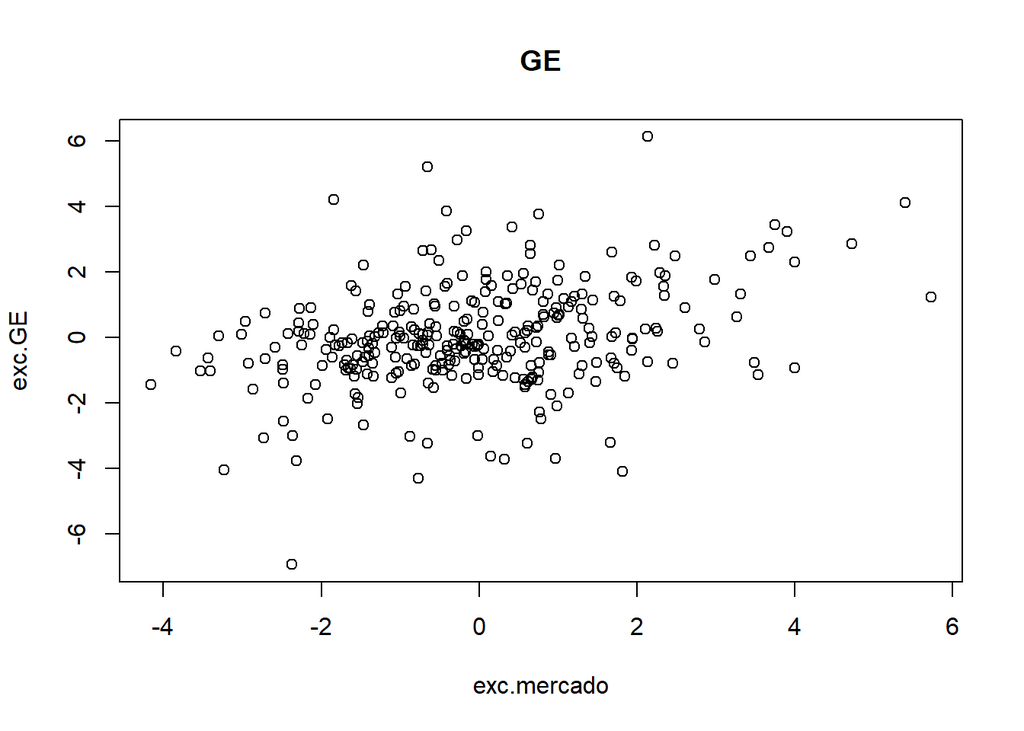

```r
plot(exc.GE~exc.mercado, main="GE")
```

**Código**

```r
ml3<-lm(exc.GE~exc.mercado)
summary(ml3)
```

```
Call:
lm(formula = exc.GE ~ exc.mercado)

Residuals:
    Min      1Q  Median      3Q     Max
-6.2032 -0.7147  0.0053  0.8268  5.4423

Coefficients:
            Estimate Std. Error t value Pr(>|t|)
(Intercept)  0.01761    0.08415   0.209    0.834
exc.mercado  0.31153    0.05168   6.028 4.73e-09 ***
---
Signif. codes:  0 '***' 0.001 '**' 0.01 '*' 0.05 '.' 0.1 ' ' 1

Residual standard error: 1.482 on 309 degrees of freedom
Multiple R-squared:  0.1052,    Adjusted R-squared:  0.1023
F-statistic: 36.34 on 1 and 309 DF,  p-value: 4.727e-09
```

**Código**

```r
t.quantil<-qt(0.025,df=n-p, lower.tail = F)
LI<-(0.31153) -  0.05168*sqrt(t.quantil)
LS<-(0.31153) +  0.05168*sqrt(t.quantil)
```

- O parâmetro $\alpha$ não é significativo para o modelo.
- IC($\beta_1$,95%) = [0.2390366; 0.3840234], o intervalo contém o verdadeiro valor do parâmetro com 95% de confiabilidade.

**Análise dos resíduos**

**Código**

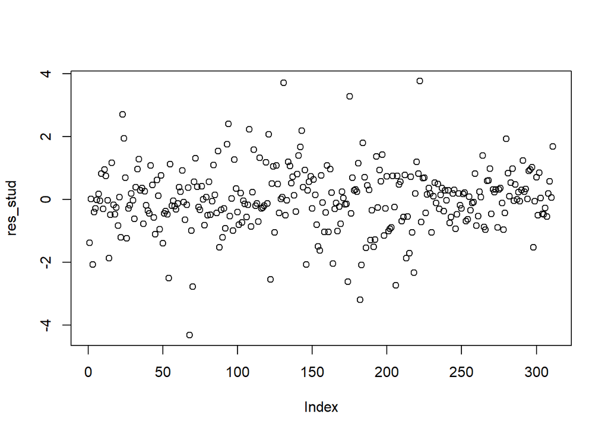

```r
y.hat<-ml3$fitted.values
res_stud<-rstudent(ml3)
plot(res_stud)
```

Temos algumas observações discrepantes: 68, 131, 175 e 222.

**Código**

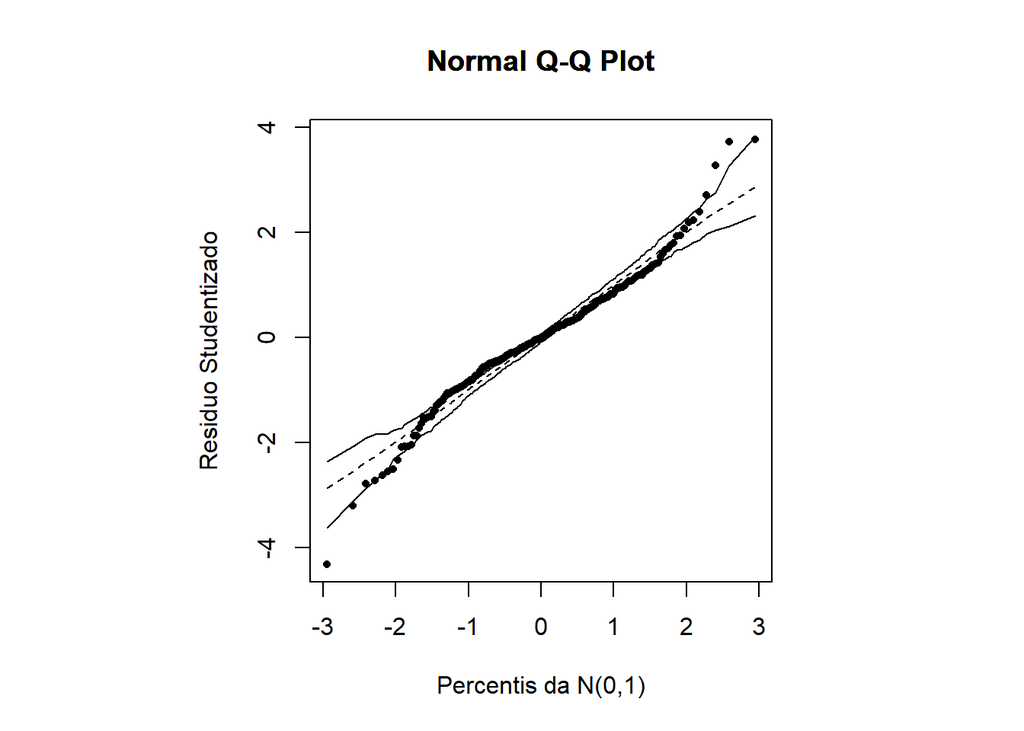

```r
envel_norm(ml3)
```

Os resíduos parecem bem comportados, apesar das observações atípicas.

**Diagnóstico**

**Código**

```r
influ<-influence.measures(ml3)
deffits=influ$infmat[,3] # conferir coluna
cook=influ$infmat[,5] # conferir coluna
Hii=influ$infmat[,6] # conferir coluna

n<-nrow(capm)
p<-2

corte=2*p/n
plot(Hii, pch=1, main='Pontos de alavanca', cex=0.5)
lines(1:n,corte*rep(1,n),lty=2, col='maroon')
```

[output not shown]

**Código**

```r
#identify(Hii, n=2, tolerance = 2)
```

Temos algumas observações como ponto de alavanca.

**Código**

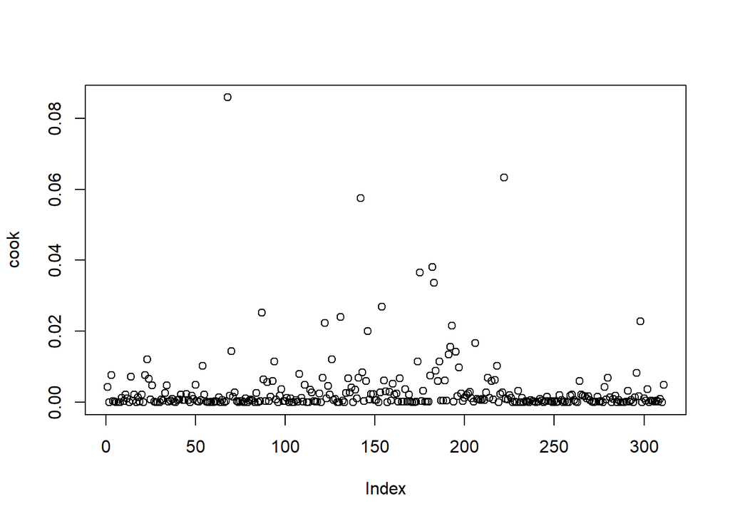

```r
corte=pf(0.5,p,n-p)
plot(cook)
lines(1:n,corte*rep(1,n), lty=2, col='maroon')
```

**Código**

```r
# identify(cook, n=2, tolerance = 1.5)
```

Nenhuma observação parece influente em termos da distância de cook.

**Código**

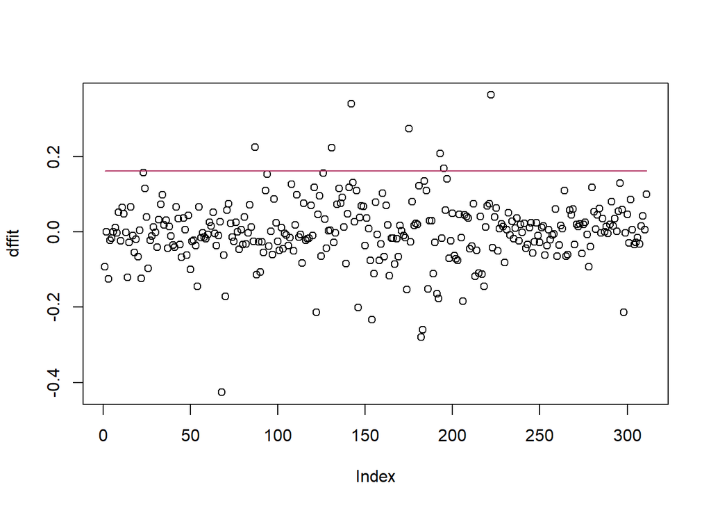

```r
dffit=influ$infmat[,3]
corte=2*sqrt(p/(n-p))
plot(dffit)
lines(1:n,corte*rep(1,n), col="maroon")
```

**Código**

```r
summary(influ)
```

```
Potentially influential observations of
     lm(formula = exc.GE ~ exc.mercado) :

    dfb.1_ dfb.exc. dffit   cov.r   cook.d hat
23   0.15  -0.03     0.16    0.96_*  0.01   0.00
54  -0.14  -0.02    -0.14    0.97_*  0.01   0.00
68  -0.23   0.35    -0.43_*  0.90_*  0.09   0.01
70  -0.15   0.07    -0.17    0.96_*  0.01   0.00
87   0.10   0.21     0.23    1.01    0.03   0.02_*
94   0.14   0.07     0.15    0.97_*  0.01   0.00
108  0.13  -0.01     0.13    0.98_*  0.01   0.00
122 -0.15  -0.16    -0.21    0.97_*  0.02   0.01
126  0.07   0.14     0.16    1.02_*  0.01   0.02_*
129  0.00   0.00     0.00    1.02_*  0.00   0.02
131  0.21  -0.07     0.22    0.93_*  0.02   0.00
```

[output cut: 21 more lines]

Algumas observações são apontadas como influentes em termos da medida Dffif, essa lista inclui as observações com resíduo alto.

## 25

- 1. o preço de venda de um imóvel (em mil USD);
- 2. a área total (em pés quadrados).

**Código**

```r
area <- c(800, 950, 910, 950, 1200, 1000, 1180, 1000,
            1380, 1250, 1500, 1200, 1600, 1650, 1600, 1680,
            1500, 1780, 1790, 1900, 1760, 1850, 1800, 1700,
            1370, 2000, 2000, 2100, 2050, 1990, 2150, 2050,
            2200, 2200, 2180, 2250, 2400, 2350, 2500, 2500,
            2500, 2500, 2680, 2210, 2750, 2500, 2400, 3100,
            2100, 4000)
preco<- c(30.6, 31.5, 33.3, 45.9, 47.4, 48.9, 51.6, 53.1,
             54.0, 54.3, 55.2, 55.2, 56.7, 57.9, 58.5, 59.7,
             60.9, 60.9, 62.4, 63.0, 64.5, 66.0, 66.3, 67.5,
             68.4, 68.4, 68.7, 69.6, 70.5, 74.7, 75.0, 75.3,
             79.8, 80.7, 80.7, 83.4, 84.0, 86.1, 87.0, 90.3,
             96.0, 101.4, 105.9, 111.3, 112.5, 114.0, 115.2, 117.0,
             129.0, 165.0)
venda <- data.frame(area,preco)
colnames(venda) <- c("area","preco")
suppressMessages(attach(venda))
```

### Análise exploratória

**Código**

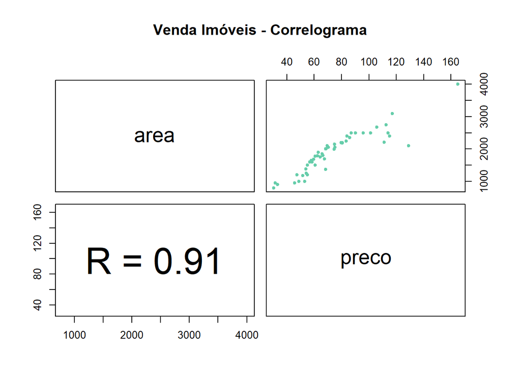

```r
pairs(venda[,c(1:2)], main = "Venda Imóveis - Correlograma", pch = 20, col="aquamarine3",
    lower.panel = painel.prop)
```

No gráfico acima temos o diagrama de dispersão do preço e da área, possuem uma correlação bem alta.

**Código**

```r
modelo<-lm(preco~area, data = venda)
```

**Código**

```r
summary(modelo)
```

```
Call:
lm(formula = preco ~ area, data = venda)

Residuals:
    Min      1Q  Median      3Q     Max
-12.445  -6.359  -3.948   4.749  46.955

Coefficients:
            Estimate Std. Error t value Pr(>|t|)
(Intercept) 1.092915   5.043642   0.217    0.829
area        0.038548   0.002525  15.268   <2e-16 ***
---
Signif. codes:  0 '***' 0.001 '**' 0.01 '*' 0.05 '.' 0.1 ' ' 1

Residual standard error: 11.06 on 48 degrees of freedom
Multiple R-squared:  0.8292,    Adjusted R-squared:  0.8257
F-statistic: 233.1 on 1 and 48 DF,  p-value: < 2.2e-16
```

### Análise de resíduos

*MODELO:* preco ~ area

**Código**

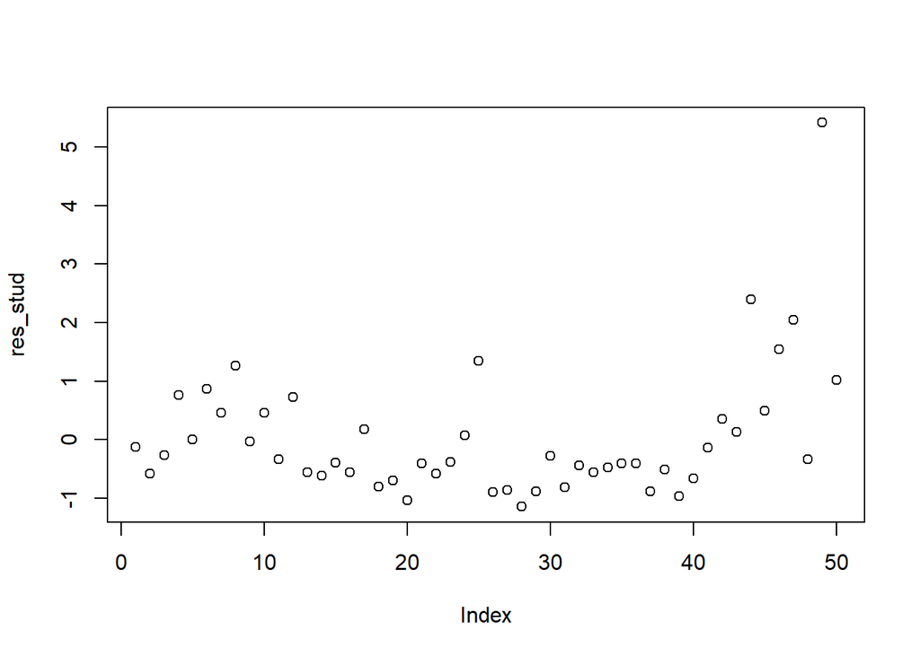

```r
y.hat<-modelo$fitted.values
res_stud<-rstudent(modelo)
res_pad<-rstandard(modelo)
plot(res_stud)
```

**Código**

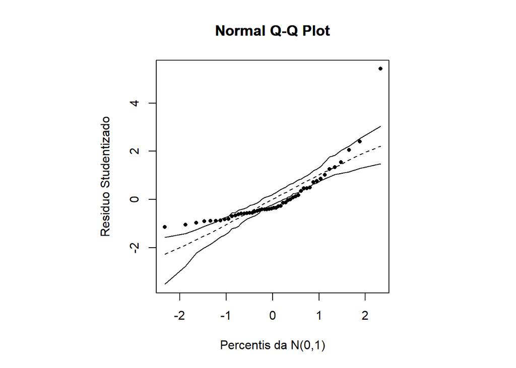

```r
envel_norm(modelo)
```

Os resíduos não podem ser considerados normalmente distribuídos.

#### Homodedasticidade

**Código**

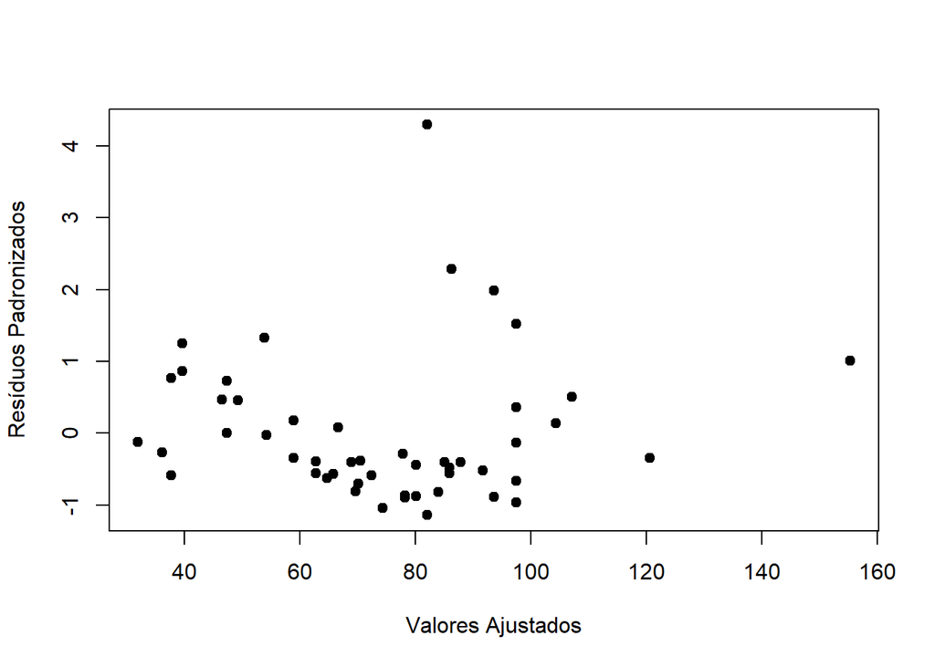

```r
plot(y.hat,res_pad,xlab="Valores Ajustados", ylab="Resíduos Padronizados",pch=19)
```

Não foi identificado padrões que indiquem que os erros são heterocedásticos.

#### Resíduo x variável explicativa

**Código**

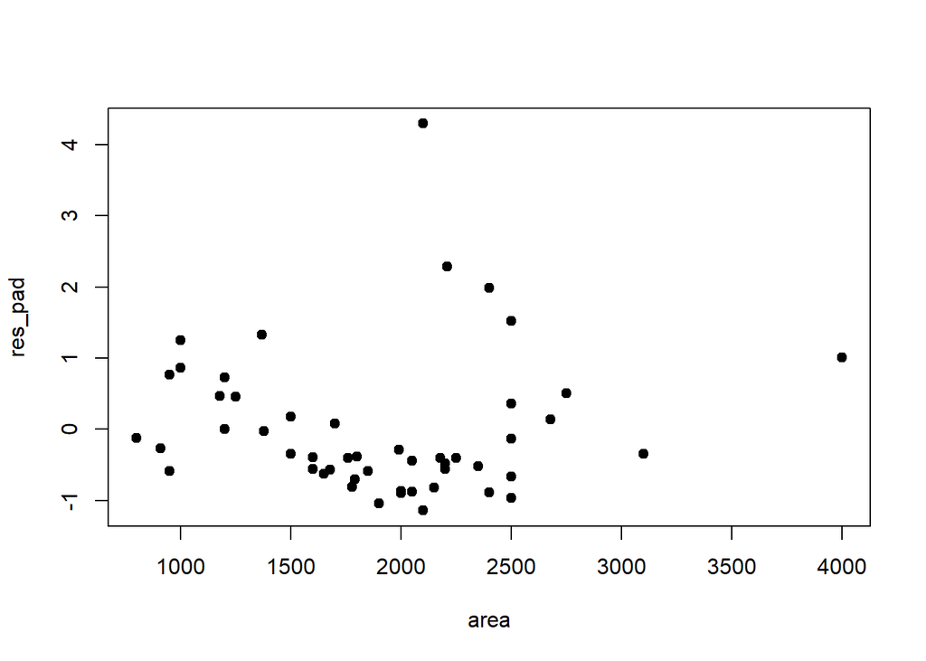

```r
plot(area, res_pad, pch=19)
```

**Modelo não validado!!!**

##### Tranformação log(preco)

Vamos tentar a transfromação log para tentar normalizar os resíduos.

**Código**

```r
modelo<-lm(log(preco)~area)
summary(modelo)
```

```
Call:
lm(formula = log(preco) ~ area)

Residuals:
     Min       1Q   Median       3Q      Max
-0.31391 -0.06854 -0.01756  0.06245  0.50823

Coefficients:
             Estimate Std. Error t value Pr(>|t|)
(Intercept) 3.278e+00  6.437e-02   50.94   <2e-16 ***
area        5.110e-04  3.222e-05   15.86   <2e-16 ***
---
Signif. codes:  0 '***' 0.001 '**' 0.01 '*' 0.05 '.' 0.1 ' ' 1

Residual standard error: 0.1411 on 48 degrees of freedom
Multiple R-squared:  0.8398,    Adjusted R-squared:  0.8364
F-statistic: 251.5 on 1 and 48 DF,  p-value: < 2.2e-16
```

**Código**

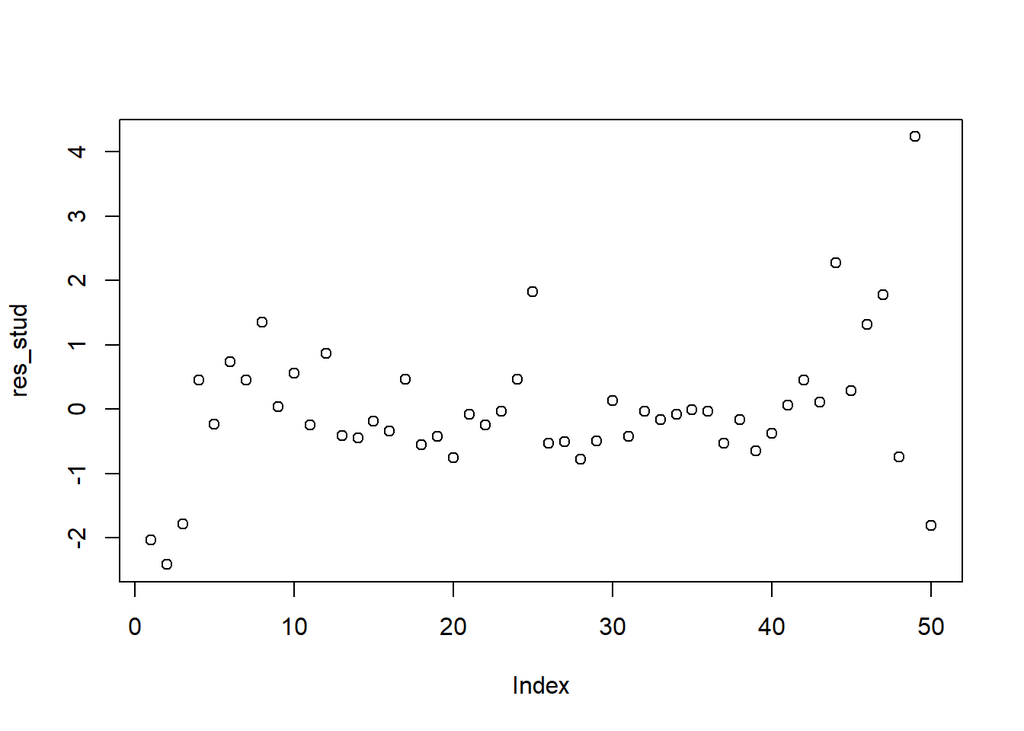

```r
y.hat<-modelo$fitted.values
res_stud<-rstudent(modelo)
res_pad<-rstandard(modelo)
plot(res_stud)
```

Observação 49 é atípica.

#### Normalidade

**Código**

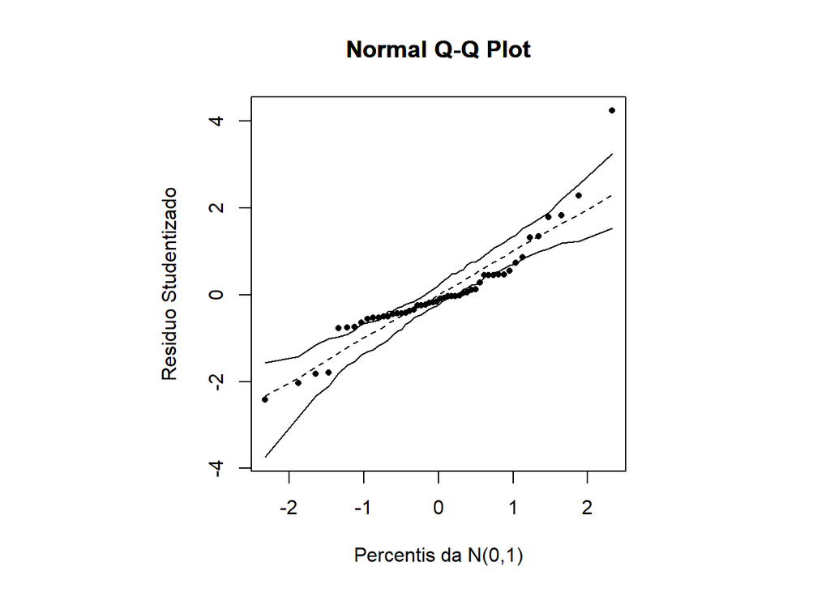

```r
envel_norm(modelo)
```

Agora parece razoável dizer que os resíduos são normalmente distribuídos.

#### Homodedasticidade

**Código**

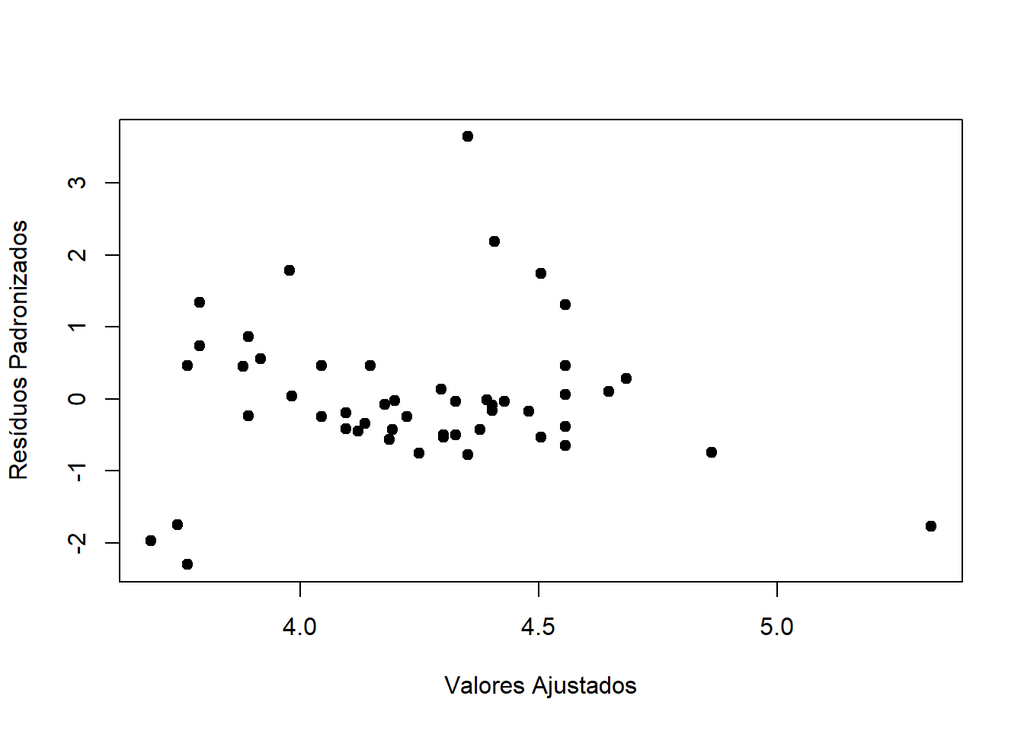

```r
plot(y.hat,res_pad,xlab="Valores Ajustados", ylab="Resíduos Padronizados",pch=19)
```

Não foi identificado padrões que indiquem que os erros são heterocedásticos.

#### Resíduo x variável explicativa

**Código**

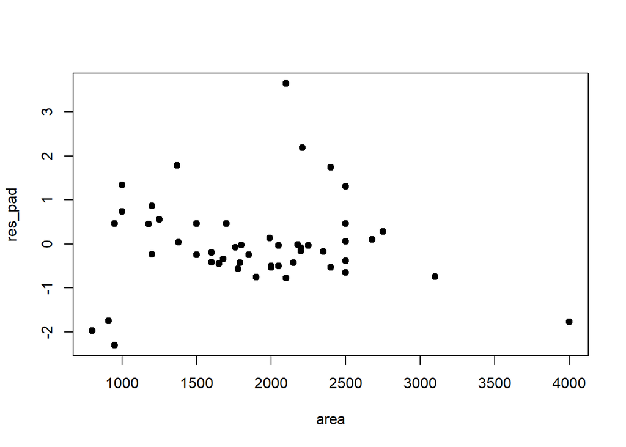

```r
plot(area, res_pad, pch=19)
```

Nenhum padrão.

**Modelo validado após a transformação: log(preco) ~ area**

### Análise de diagnóstico

**Código**

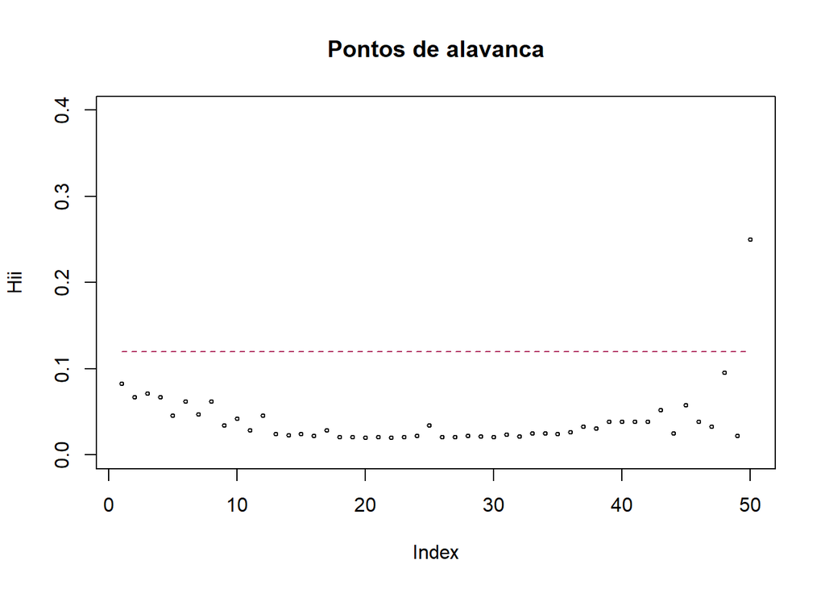

```r
influ<-influence.measures(modelo)
deffits=influ$infmat[,3] # conferir coluna
cook=influ$infmat[,5] # conferir coluna
Hii=influ$infmat[,6] # conferir coluna

n<-nrow(venda)
p<-3

corte=2*p/n
plot(Hii, pch=1, main='Pontos de alavanca', cex=0.5, ylim=c(0,0.4))
lines(1:n,corte*rep(1,n),lty=2, col='maroon')
```

**Código**

```r
#identify(Hii, n=2, tolerance = 2)
```

**Código**

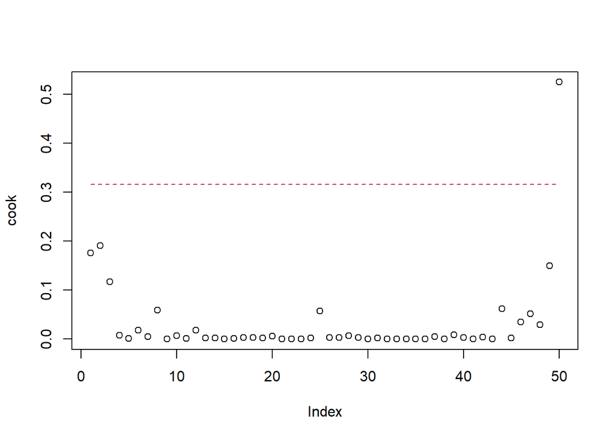

```r
corte=pf(0.5,p,n-p)
plot(cook)
lines(1:n,corte*rep(1,n), lty=2, col='maroon')
```

**Código**

```r
# identify(cook, n=2, tolerance = 1.5)
```

A observação 50 também parece ser influente.

**Código**

```r
summary(influ)
```

```
Potentially influential observations of
     lm(formula = log(preco) ~ area) :

   dfb.1_ dfb.area dffit   cov.r   cook.d hat
2  -0.63   0.54    -0.65_*  0.88    0.19   0.07
44 -0.05   0.16     0.37    0.87_*  0.06   0.03
48  0.17  -0.21    -0.24    1.13_*  0.03   0.10
49  0.00   0.20     0.64_*  0.56_*  0.15   0.02
50  0.86  -1.01_*  -1.05_*  1.21_*  0.52   0.25_*
```

A observação 50 é preocupante.

# Parte B

Ajustar modelos de regressão aos dados (y_ex1.txt,X_ex1.txt), (y_ex2.txt,X_ex2.txt) e (y_ex3.txt,X_ex3.txt). Verificar pressupostos e fazer eventuais correções.

## Exemplo 1

**Código**

```r
suppressMessages(y_ex1 <- read.table("C:/ufjf/2024.3/ModelosLinearesGeneralizados/dados/lista1/y_ex1.txt", quote="\"", comment.char=""))

library(readr)
X_ex1 <- read_table("dados/lista1/X_ex1.txt")
```

**Código**

```r
d1<-cbind(y_ex1,X_ex1)
suppressMessages(colnames(d1)<-c("y","x1","x2","x3"))
```

### Análise exploratória

**Código**

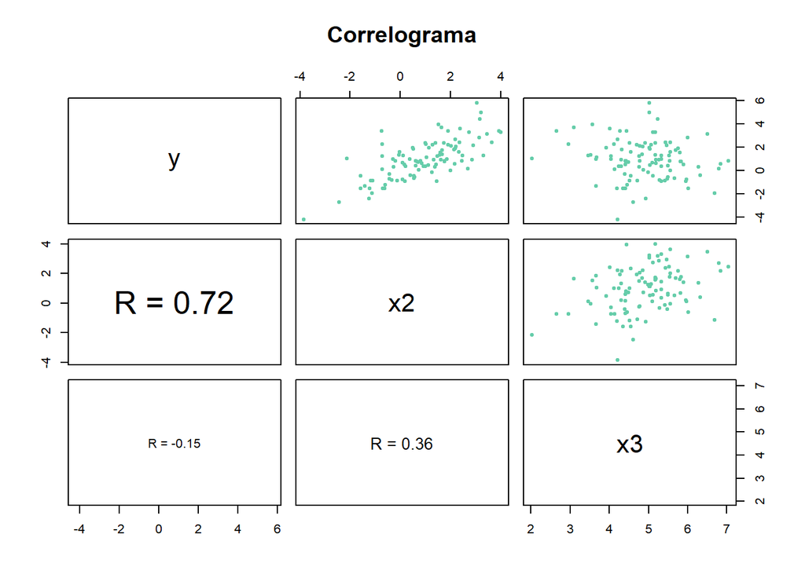

```r
pairs(d1[,c(1,3,4)], main = "Correlograma", pch = 20, col="aquamarine3",
    lower.panel = painel.prop)
```

No gráfico acima temos o diagrama de dispersão das explicativas com a resposta.

**Código**

```r
suppressMessages(attach(d1))
modelo<-lm(y~1+x2+x3, data = d1)
summary(modelo)
```

```
Call:
lm(formula = y ~ 1 + x2 + x3, data = d1)

Residuals:
    Min      1Q  Median      3Q     Max
-2.0437 -0.5583 -0.0551  0.6439  2.7959

Coefficients:
            Estimate Std. Error t value Pr(>|t|)
(Intercept)   4.3423     0.5339   8.134 1.39e-12 ***
x2            1.0012     0.0659  15.193  < 2e-16 ***
x3           -0.8842     0.1109  -7.971 3.09e-12 ***
---
Signif. codes:  0 '***' 0.001 '**' 0.01 '*' 0.05 '.' 0.1 ' ' 1

Residual standard error: 0.919 on 97 degrees of freedom
Multiple R-squared:  0.7107,    Adjusted R-squared:  0.7047
F-statistic: 119.1 on 2 and 97 DF,  p-value: < 2.2e-16
```

### Análise de resíduos

**Código**

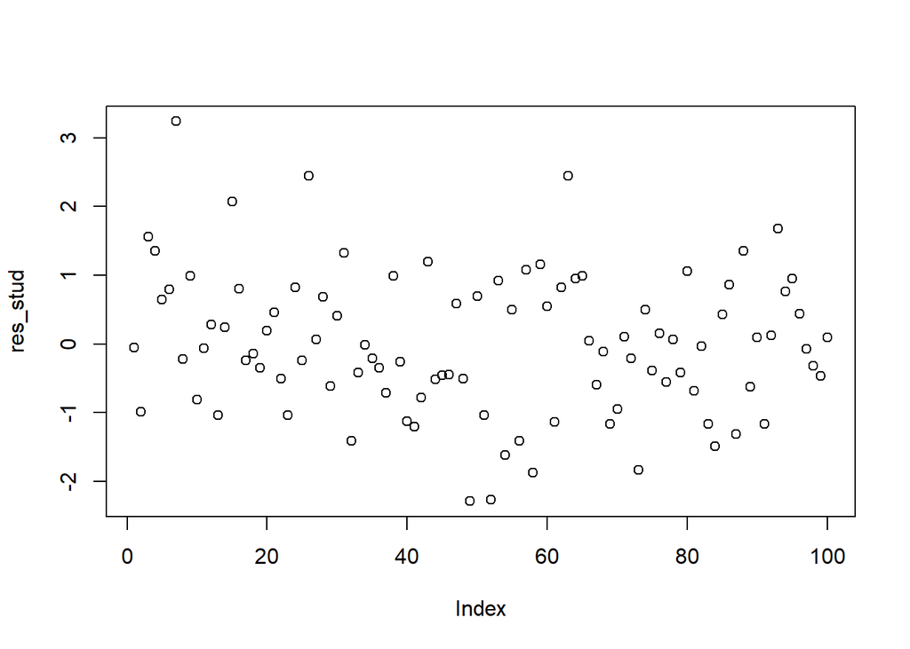

```r
y.hat<-modelo$fitted.values
res_stud<-rstudent(modelo)
res_pad<-rstandard(modelo)
plot(res_stud)
```

#### Normalidade

**Código**

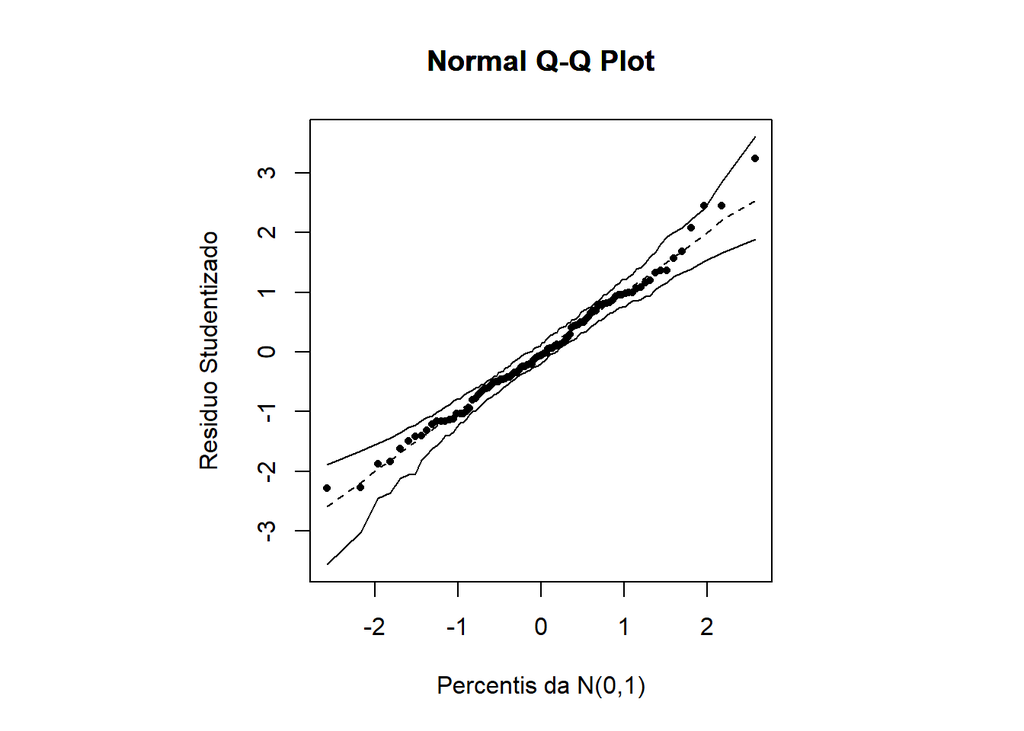

```r
envel_norm(modelo)
```

Os resíduos estão bem comportados e podemos assumir normalidade.

#### Homodedasticidade

**Código**

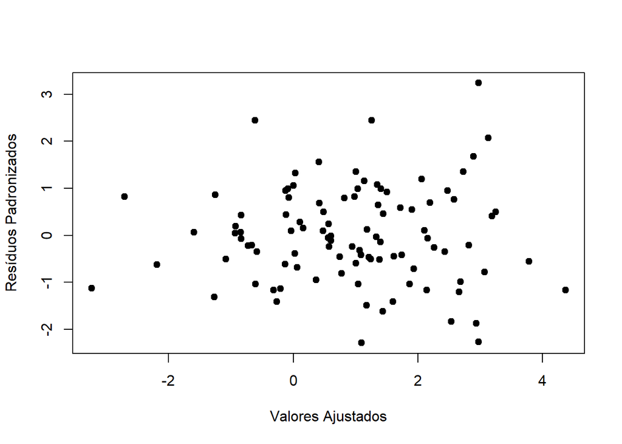

```r
plot(y.hat,res_stud,xlab="Valores Ajustados", ylab="Resíduos Padronizados",pch=19)
```

Não foi identificado padrões que indiquem que os erros são heterocedásticos.

#### Resíduo x variável explicativa

**Código**

```r
attach(d1)
```

**Código**

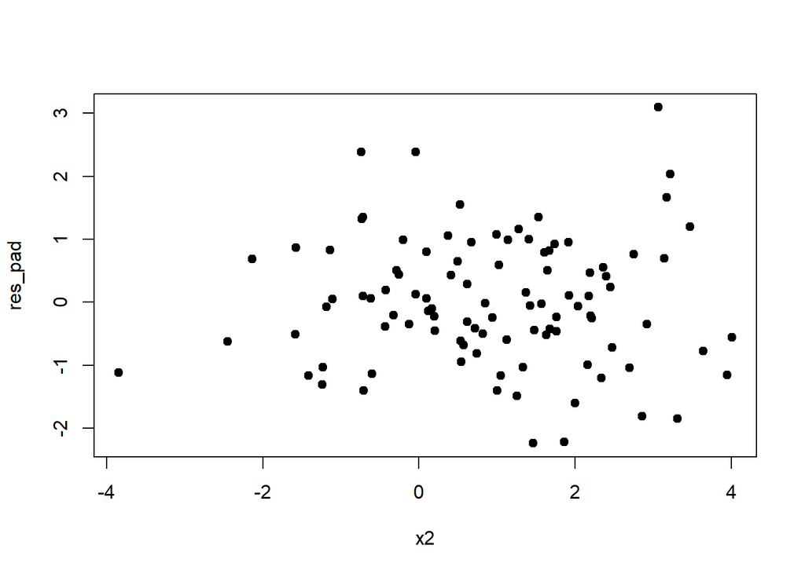

```r
plot(x2, res_pad, pch=19)
```

**Código**

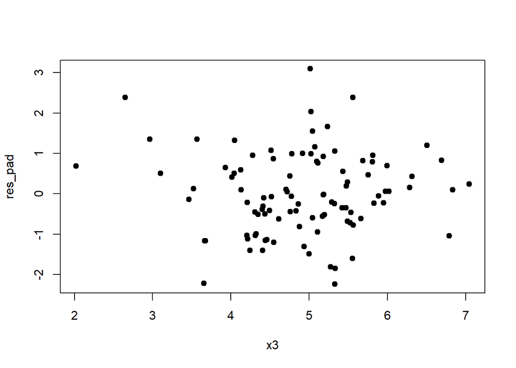

```r
plot(x3, res_pad, pch=19)
```

Não parece haver mais nenhuma contribuição das variáveis explicativas.

**Modelo y ~ 1+ x2 + x3 validado, os presuposto foram atendidos!!!**

## Exemplo 2

**Código**

```r
suppressMessages(y_ex2 <- read.table("C:/ufjf/2024.3/ModelosLinearesGeneralizados/dados/lista1/y_ex2.txt", quote="\"", comment.char=""))

library(readr)
X_ex2 <- read_table("dados/lista1/X_ex2.txt",
    col_names = FALSE)
```

**Código**

```r
d2<-cbind(y_ex2,X_ex2)
suppressMessages(colnames(d2)<-c("y","x1","x2","x3"))
```

### Análise exploratória

**Código**

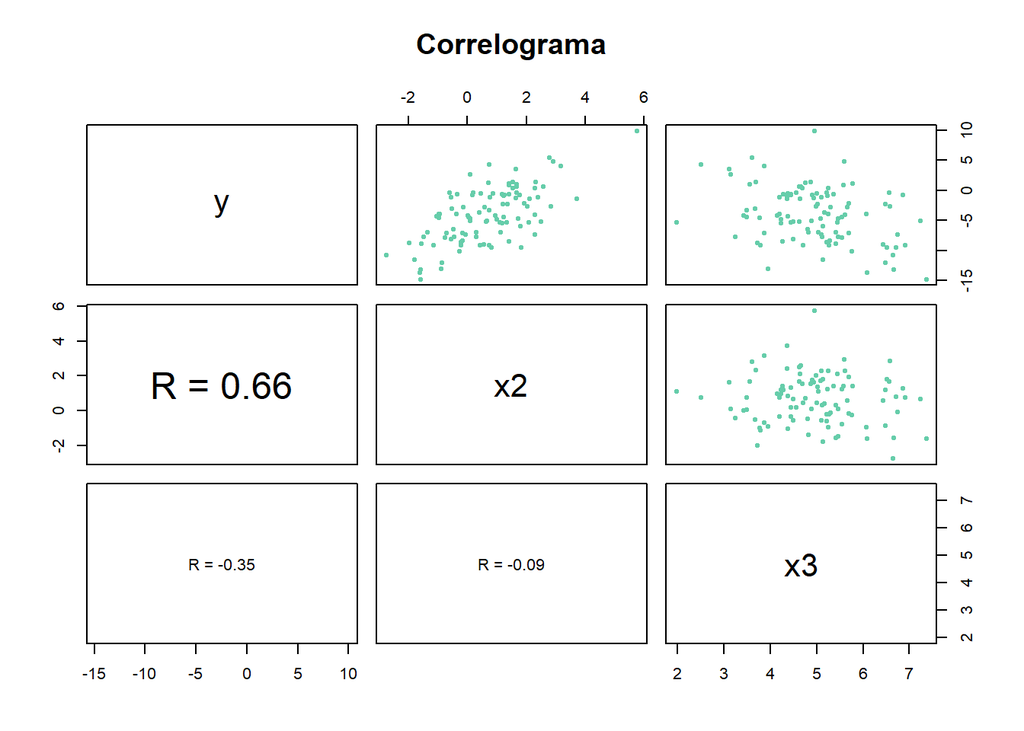

```r
pairs(d2[,c(1,3,4)], main = "Correlograma", pch = 20, col="aquamarine3",
    lower.panel = painel.prop)
```

No gráfico acima temos o diagrama de dispersão das explicativas com a resposta.

**Código**

```r
suppressMessages(attach(d2))
modelo<-lm(y~1+x2+x3, data = d1)
summary(modelo)
```

```
Call:
lm(formula = y ~ 1 + x2 + x3, data = d1)

Residuals:
    Min      1Q  Median      3Q     Max
-2.0437 -0.5583 -0.0551  0.6439  2.7959

Coefficients:
            Estimate Std. Error t value Pr(>|t|)
(Intercept)   4.3423     0.5339   8.134 1.39e-12 ***
x2            1.0012     0.0659  15.193  < 2e-16 ***
x3           -0.8842     0.1109  -7.971 3.09e-12 ***
---
Signif. codes:  0 '***' 0.001 '**' 0.01 '*' 0.05 '.' 0.1 ' ' 1

Residual standard error: 0.919 on 97 degrees of freedom
Multiple R-squared:  0.7107,    Adjusted R-squared:  0.7047
F-statistic: 119.1 on 2 and 97 DF,  p-value: < 2.2e-16
```

### Análise de resíduos

**Código**

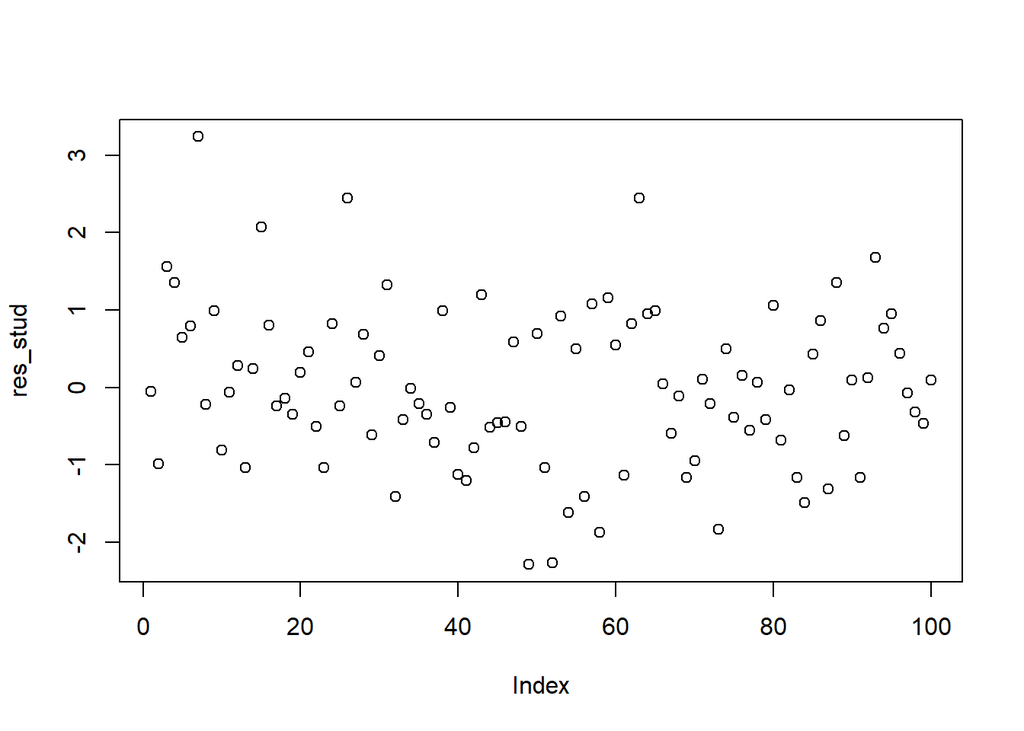

```r
y.hat<-modelo$fitted.values
res_stud<-rstudent(modelo)
res_pad<-rstandard(modelo)
plot(res_stud)
```

#### Normalidade

**Código**

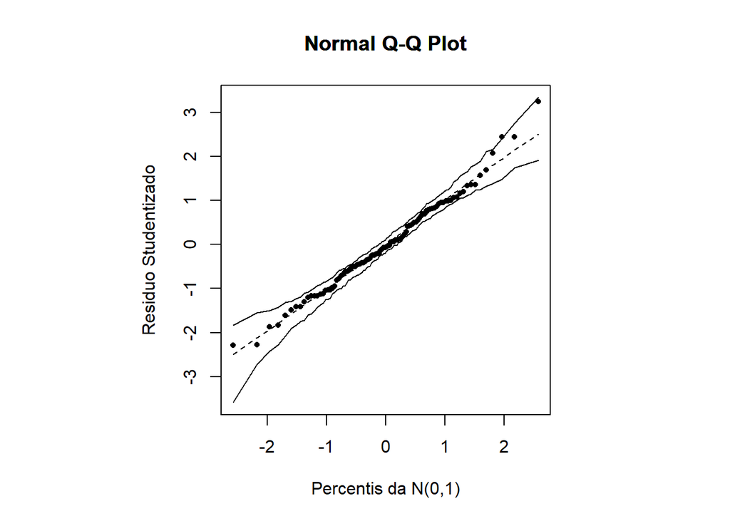

```r
envel_norm(modelo)
```

Os resíduos estão bem comportados e podemos assumir normalidade.

#### Homodedasticidade

**Código**

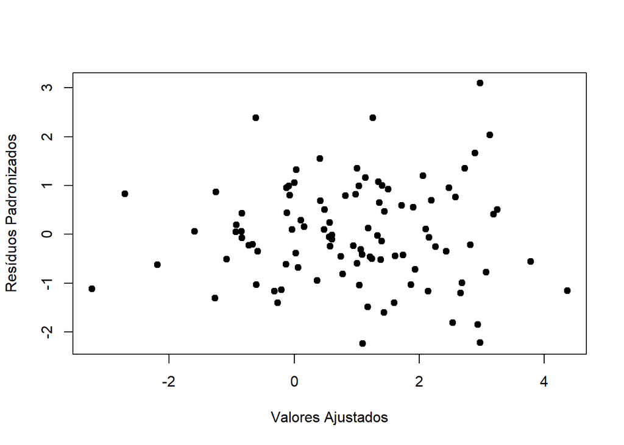

```r
plot(y.hat,res_pad,xlab="Valores Ajustados", ylab="Resíduos Padronizados",pch=19)
```

Não foi identificado padrões que indiquem que os erros são heterocedásticos.

#### Resíduo x variável explicativa

**Código**

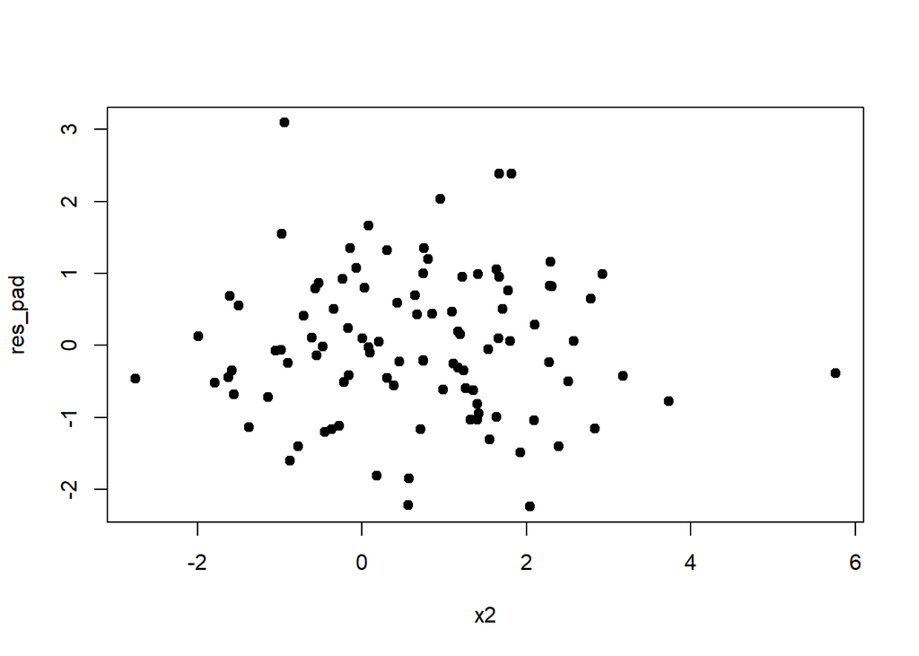

```r
suppressMessages(attach(d2))
plot(x2, res_pad, pch=19)
```

**Código**

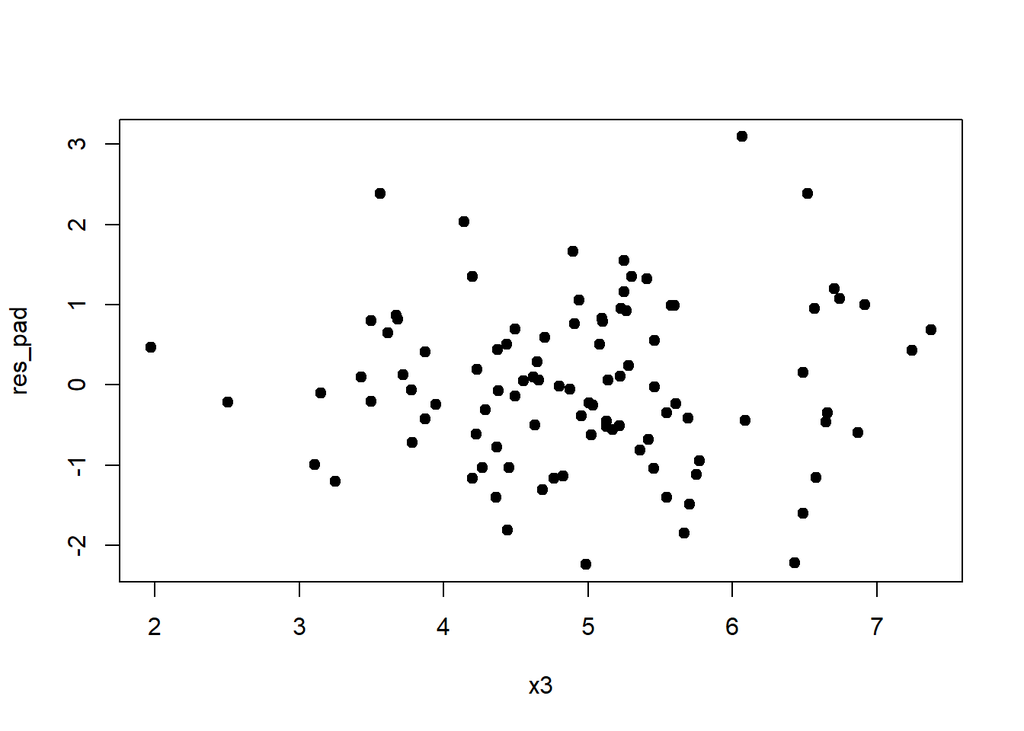

```r
plot(x3, res_pad, pch=19)
```

Não parece haver mais nenhuma contribuição das variáveis explicativas.

## Exemplo 3

**Código**

```r
suppressMessages(y_ex3 <- read.table("C:/ufjf/2024.3/ModelosLinearesGeneralizados/dados/lista1/y_ex3.txt", quote="\"", comment.char=""))

library(readr)
X_ex3 <- read_table("dados/lista1/X_ex3.txt",
    col_names = FALSE)
```

**Código**

```r
d3<-cbind(y_ex3,X_ex3)
suppressMessages(colnames(d3)<-c("y","x1","x2","x3"))
```

### Análise exploratória

**Código**

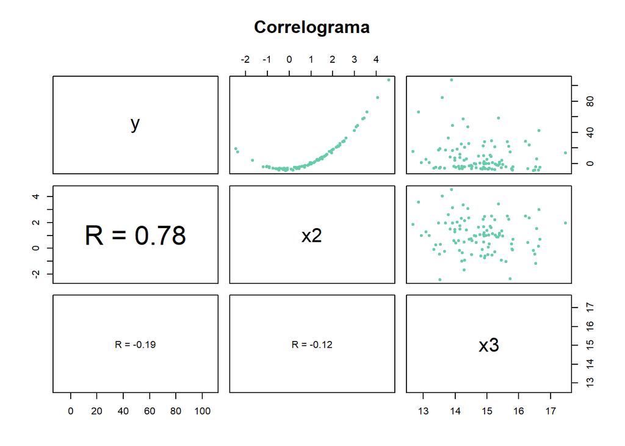

```r
pairs(d3[,c(1,3,4)], main = "Correlograma", pch = 20, col="aquamarine3",
      lower.panel = painel.prop)
```

No gráfico acima temos o diagrama de dispersão das explicativas com a resposta. A variável possui um relacionamento não linear com a resposta.

**Código**

```r
suppressMessages(attach(d3))
modelo<-lm(y~1+x2+x3, data = d3)
summary(modelo)
```

```
Call:
lm(formula = y ~ 1 + x2 + x3, data = d3)

Residuals:
    Min      1Q  Median      3Q     Max
-11.022  -7.924  -5.101   2.952  54.044

Coefficients:
            Estimate Std. Error t value Pr(>|t|)
(Intercept)  29.1493    19.9142   1.464    0.146
x2           11.9629     0.9738  12.284   <2e-16 ***
x3           -2.2009     1.3357  -1.648    0.103
---
Signif. codes:  0 '***' 0.001 '**' 0.01 '*' 0.05 '.' 0.1 ' ' 1

Residual standard error: 12.74 on 97 degrees of freedom
Multiple R-squared:  0.6233,    Adjusted R-squared:  0.6155
F-statistic: 80.24 on 2 and 97 DF,  p-value: < 2.2e-16
```

### Seleção de variáveis

**Código**

```r
stepAIC(modelo, direction = "backward")
```

```
Start:  AIC=511.85
y ~ 1 + x2 + x3

       Df Sum of Sq   RSS    AIC
<none>              15736 511.85
- x3    1     440.5 16177 512.62
- x2    1   24481.5 40218 603.69
```

```
Call:
lm(formula = y ~ 1 + x2 + x3, data = d3)

Coefficients:
(Intercept)           x2           x3
     29.149       11.963       -2.201
```

O intercepto e x3 não são significativas, porém o modelo com ela é o que possui menor AIC.

**MODELO:** y ~ 1 + x2 + x3

### Análise de resíduos

**Código**

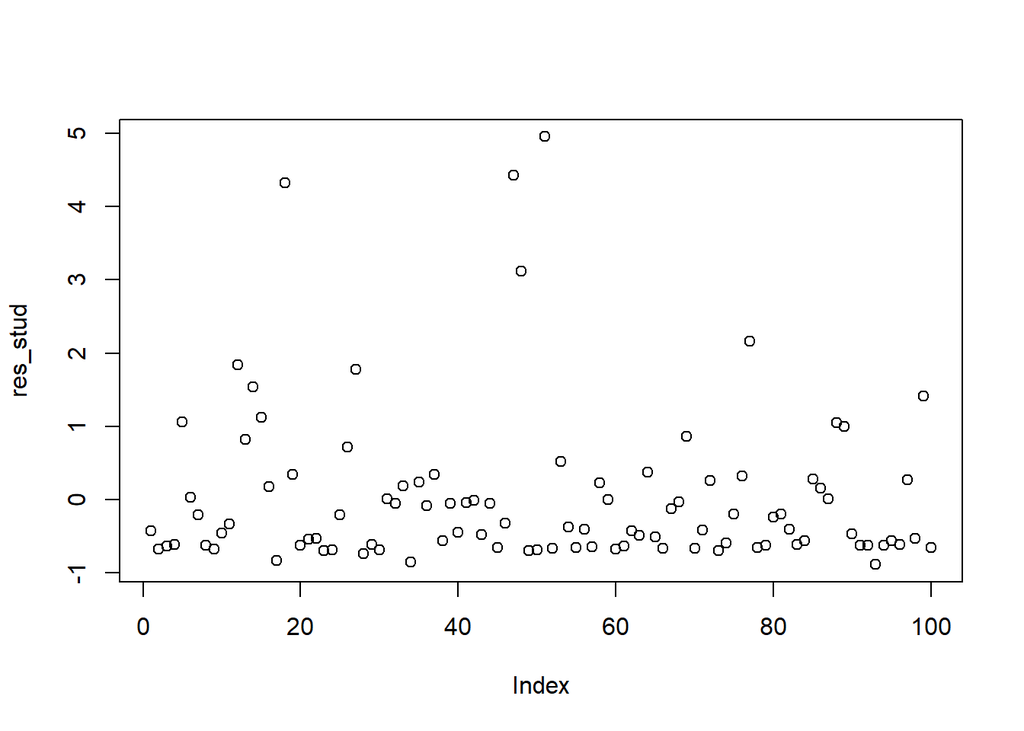

```r
y.hat<-modelo$fitted.values
res_stud<-rstudent(modelo)
res_pad<-rstandard(modelo)
plot(res_stud)
```

#### Normalidade

**Código**

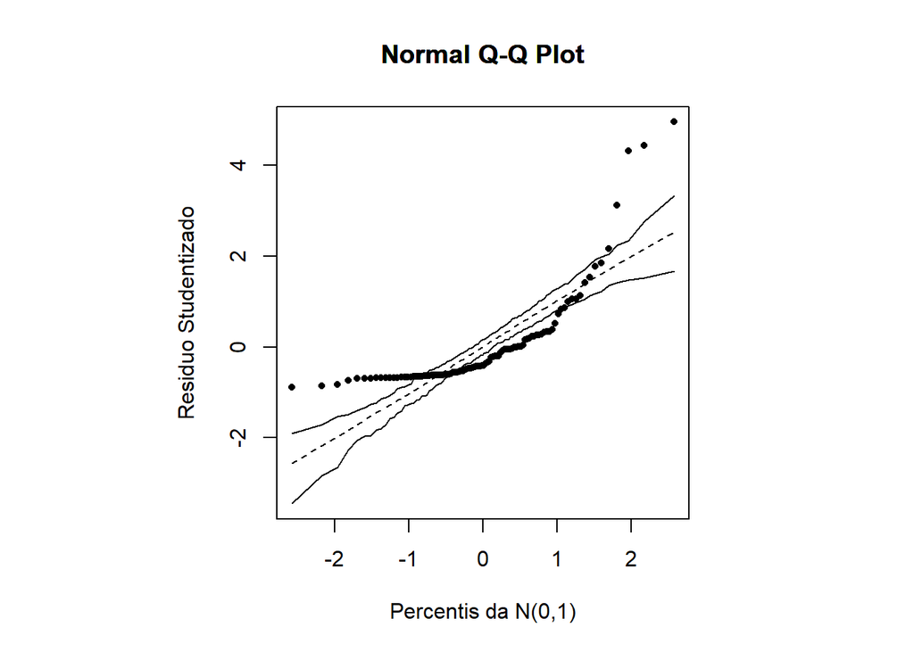

```r
envel_norm(modelo)
```

Os resíduos não podem ser considerados normais.

#### Homodedasticidade

**Código**

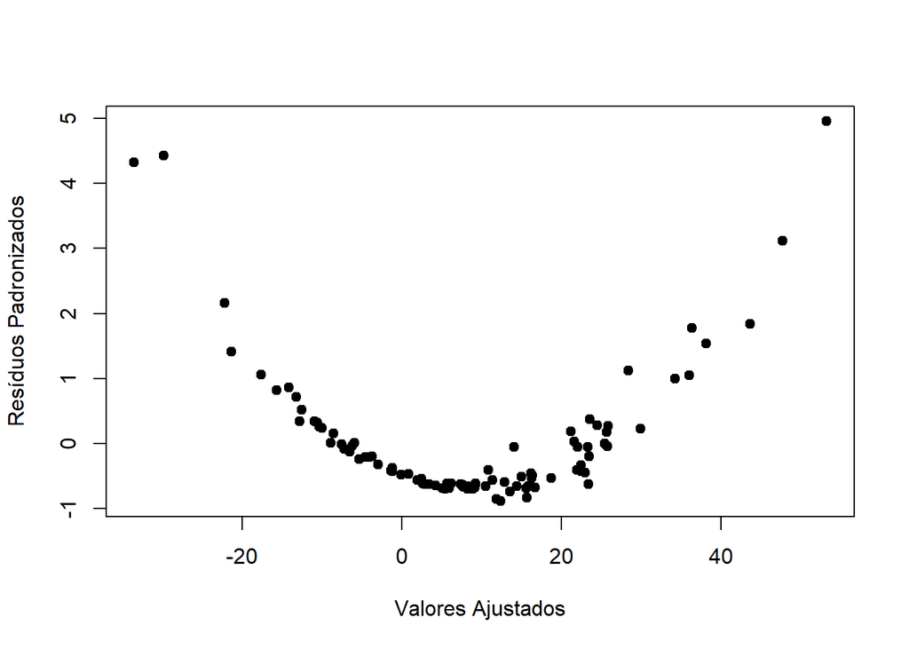

```r
plot(y.hat,res_stud,xlab="Valores Ajustados", ylab="Resíduos Padronizados",pch=19)
```

O padrão nos resíduos é igual ao do gráfico de dispersão da variável x2 com a resposta.

#### Resíduo x variável explicativa

**Código**

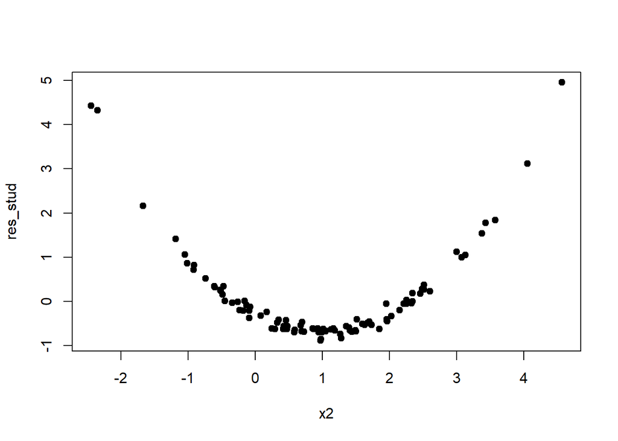

```r
plot(x2, res_stud, pch=19)
```

**Código**

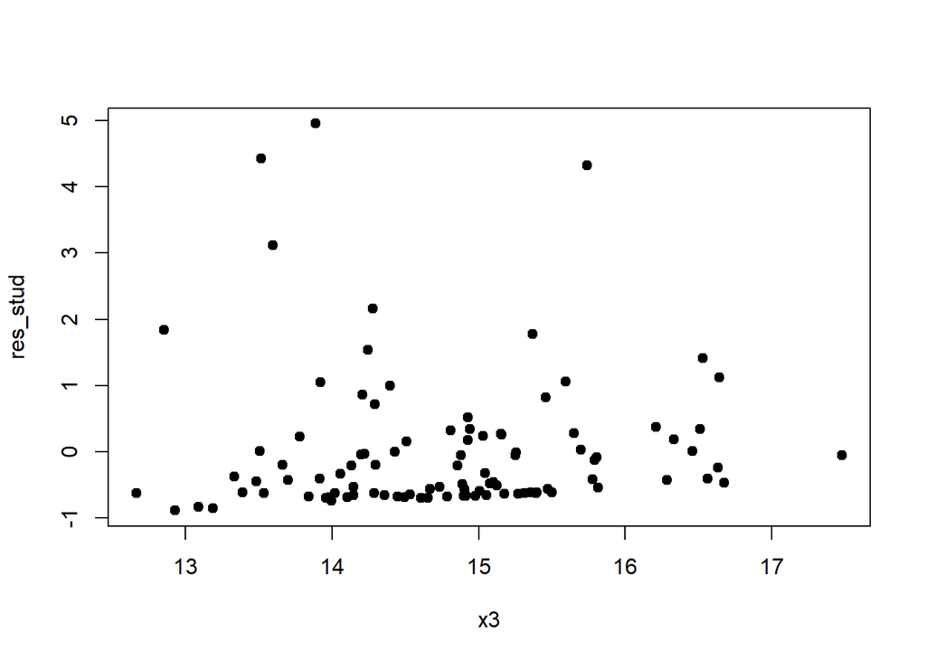

```r
plot(x3, res_stud, pch=19)
```

Vamos incluir a variável $x_2^2$.

**Modelo y ~ 1+ x2 + x3 não está validado validado, os presuposto não foram atendidos!!!**

**MODELO:** y ~ 1 + x2 + x3 + x2^2

**Código**

```r
modelo<-lm(y~1+x2+x3+I(x2^2))
summary(modelo)
```

```
Call:
lm(formula = y ~ 1 + x2 + x3 + I(x2^2))

Residuals:
       Min         1Q     Median         3Q        Max
-0.0117776 -0.0002733  0.0011081  0.0018114  0.0024565

Coefficients:
              Estimate Std. Error t value Pr(>|t|)
(Intercept)  6.6962829  0.0044070    1519   <2e-16 ***
x2           1.9999923  0.0003087    6478   <2e-16 ***
x3          -0.9326677  0.0002950   -3161   <2e-16 ***
I(x2^2)      4.9998988  0.0001116   44795   <2e-16 ***
---
Signif. codes:  0 '***' 0.001 '**' 0.01 '*' 0.05 '.' 0.1 ' ' 1

Residual standard error: 0.0028 on 96 degrees of freedom
Multiple R-squared:      1, Adjusted R-squared:      1
F-statistic: 1.775e+09 on 3 and 96 DF,  p-value: < 2.2e-16
```

### Análise de resíduos

**Código**

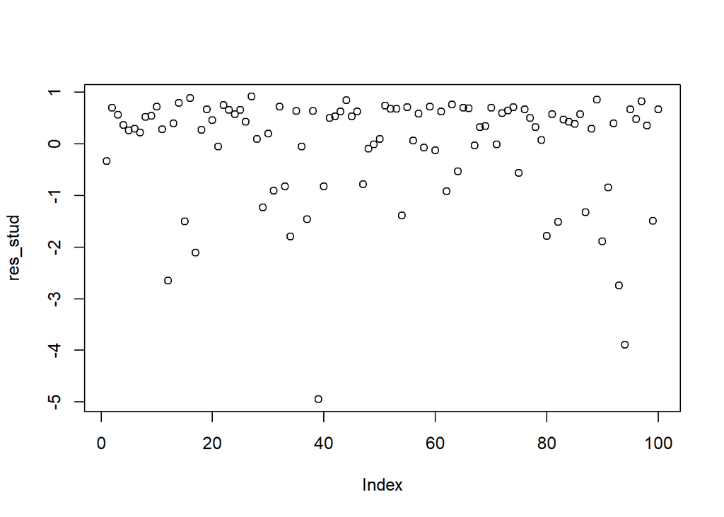

```r
y.hat<-modelo$fitted.values
res_stud<-rstudent(modelo)
res_pad<-rstandard(modelo)
plot(res_stud)
```

#### Normalidade

**Código**

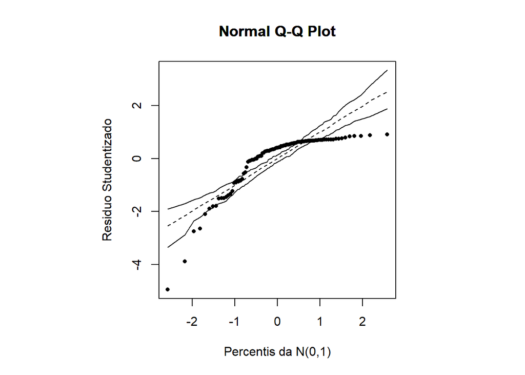

```r
envel_norm(modelo)
```

Os resíduos ainda não podem ser considerados normais.

#### Homodedasticidade

**Código**

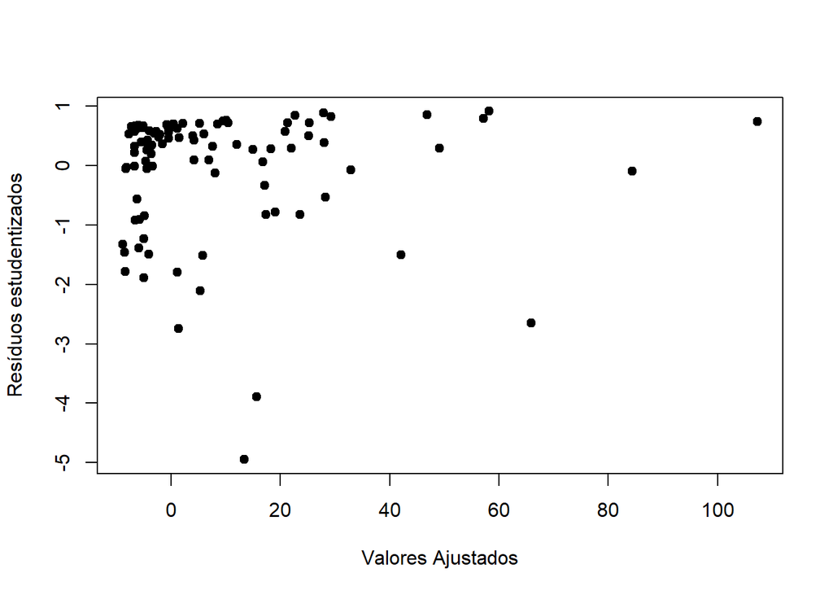

```r
plot(y.hat,res_stud,xlab="Valores Ajustados", ylab="Resíduos estudentizados",pch=19)
```

Os resíduos não parecem ter variância constante.

#### Resíduo x variável explicativa

**Código**

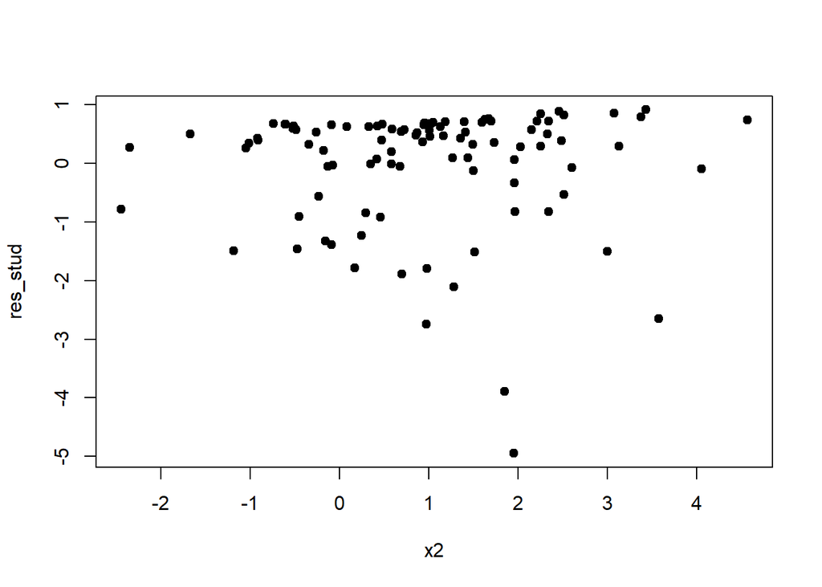

```r
plot(x2, res_stud, pch=19)
```

**Código**

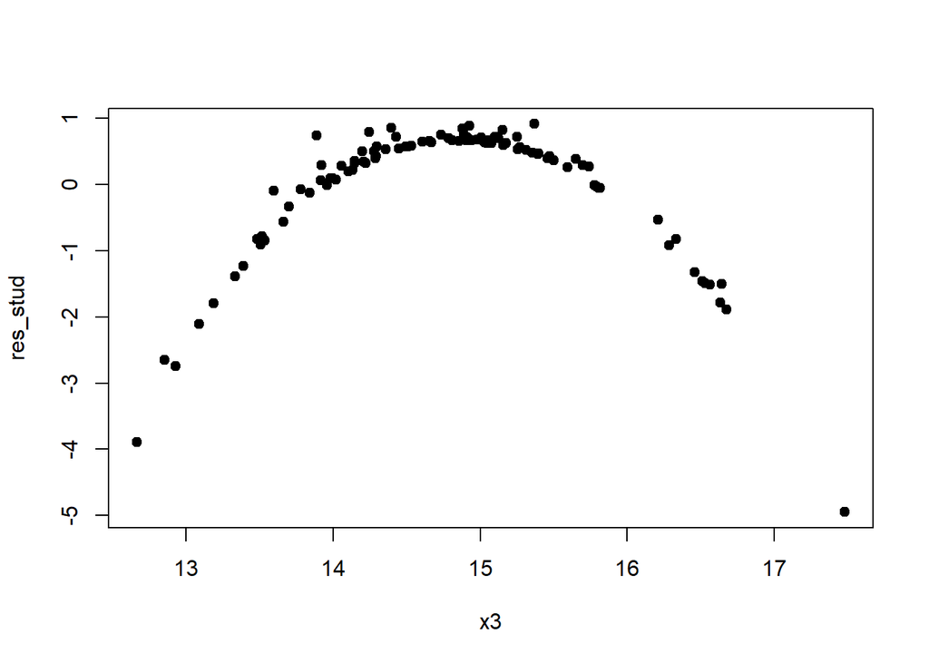

```r
plot(x3, res_stud, pch=19)
```

Vamos incluir a variável $x_3^2$.

**Modelo y ~ 1+ x2 + x2^2 + x3 não está validado validado, os presuposto não foram atendidos!!!**

### Mudanças

**Código**

```r
modelo<-lm(y~1+x2+x3+I(x2^2)+I(x3^2))
summary(modelo)
```

```
Call:
lm(formula = y ~ 1 + x2 + x3 + I(x2^2) + I(x3^2))

Residuals:
       Min         1Q     Median         3Q        Max
-6.764e-04 -1.001e-04 -6.590e-06  1.066e-04  8.790e-04

Coefficients:
              Estimate Std. Error  t value Pr(>|t|)
(Intercept)  6.196e+00  3.033e-03   2042.9   <2e-16 ***
x2           2.000e+00  1.825e-05 109578.0   <2e-16 ***
x3          -8.654e-01  4.072e-04  -2124.9   <2e-16 ***
I(x2^2)      5.000e+00  6.628e-06 754360.9   <2e-16 ***
I(x3^2)     -2.257e-03  1.365e-05   -165.4   <2e-16 ***
---
Signif. codes:  0 '***' 0.001 '**' 0.01 '*' 0.05 '.' 0.1 ' ' 1

Residual standard error: 0.0001656 on 95 degrees of freedom
Multiple R-squared:      1, Adjusted R-squared:      1
F-statistic: 3.81e+11 on 4 and 95 DF,  p-value: < 2.2e-16
```

### Análise de resíduos

**Código**

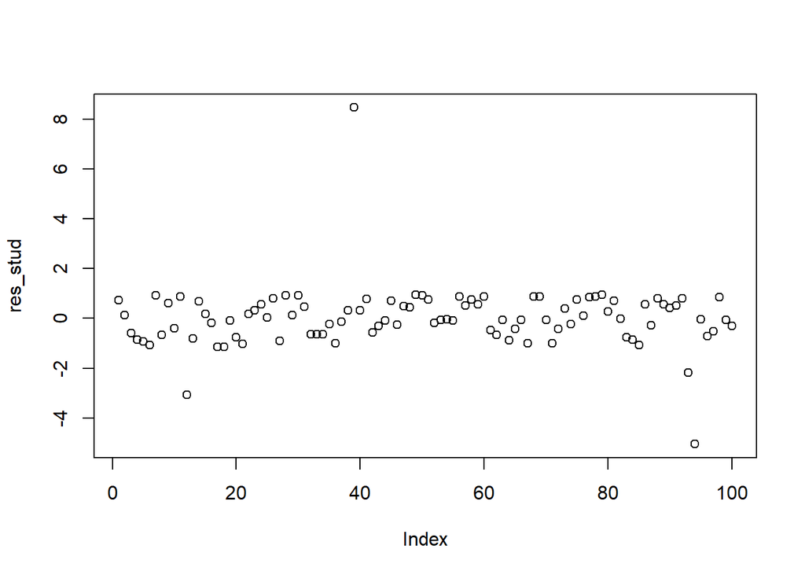

```r
y.hat<-modelo$fitted.values
res_stud<-rstudent(modelo)
res_pad<-rstandard(modelo)
plot(res_stud)
```

#### Normalidade

**Código**

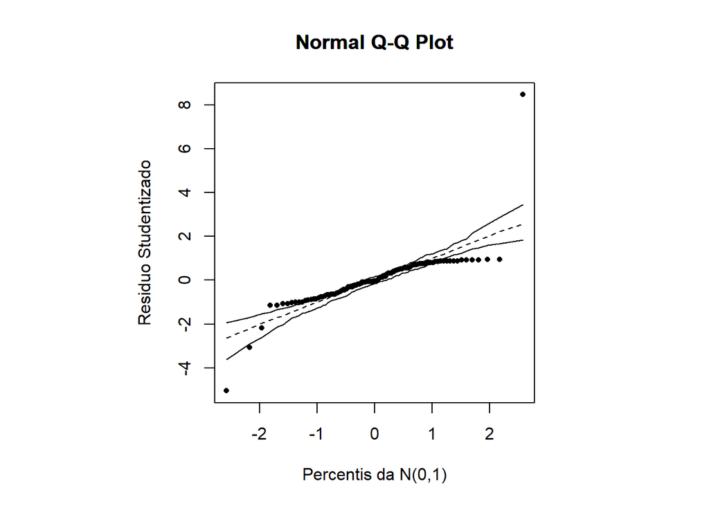

```r
envel_norm(modelo)
```

Os resíduos ainda não seguindo uma normal.

#### Homodedasticidade

**Código**

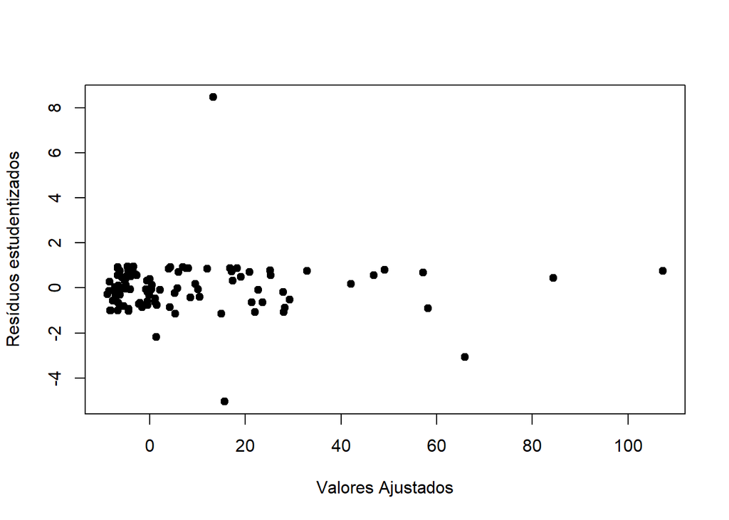

```r
plot(y.hat,res_stud,xlab="Valores Ajustados", ylab="Resíduos estudentizados",pch=19)
```

Os resíduos não parecem ter variância constante.

#### Resíduo x variável explicativa

**Código**

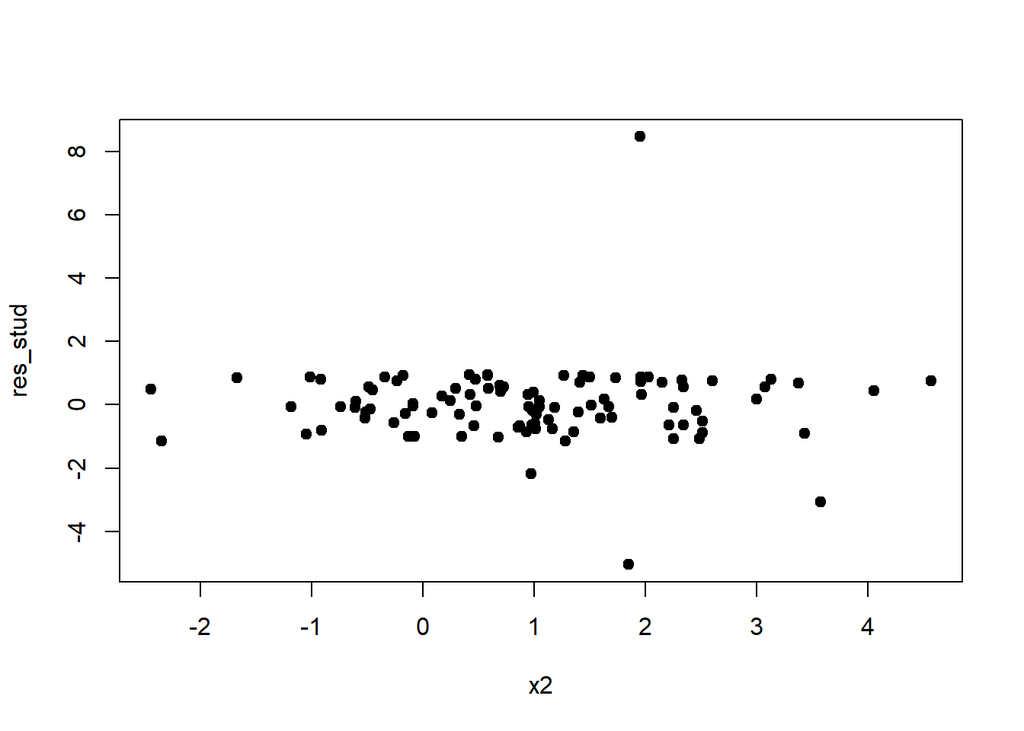

```r
plot(x2, res_stud, pch=19)
```

**Código**

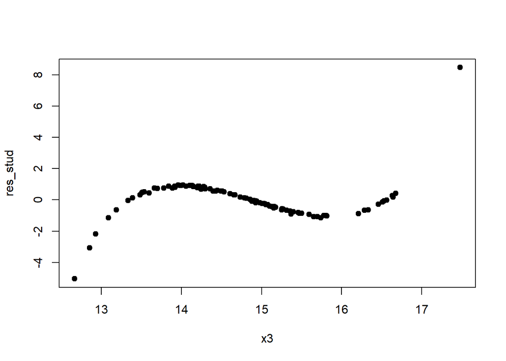

```r
plot(x3, res_stud, pch=19)
```

Vamos incluir a variável $x_3^3$.

**Modelo y ~ 1+ x2 + x2^2 + x3 + x3^2 não está validado, os presuposto não foram atendidos!!!**

### Mudanças

**Código**

```r
modelo<-lm(y~1+x2+x3+I(x2^2)+I(x3^2)+I(x3^3))
summary(modelo)
```

```
Call:
lm(formula = y ~ 1 + x2 + x3 + I(x2^2) + I(x3^2) + I(x3^3))

Residuals:
       Min         1Q     Median         3Q        Max
-5.531e-05 -6.213e-06 -1.765e-06  7.996e-06  1.742e-05

Coefficients:
              Estimate Std. Error    t value Pr(>|t|)
(Intercept)  5.865e+00  2.353e-03     2492.2   <2e-16 ***
x2           2.000e+00  1.255e-06  1593217.0   <2e-16 ***
x3          -7.983e-01  4.747e-04    -1681.7   <2e-16 ***
I(x2^2)      5.000e+00  4.558e-07 10969906.3   <2e-16 ***
I(x3^2)     -6.756e-03  3.183e-05     -212.3   <2e-16 ***
I(x3^3)      1.003e-04  7.091e-07      141.4   <2e-16 ***
---
Signif. codes:  0 '***' 0.001 '**' 0.01 '*' 0.05 '.' 0.1 ' ' 1

Residual standard error: 1.138e-05 on 94 degrees of freedom
Multiple R-squared:      1, Adjusted R-squared:      1
F-statistic: 6.447e+13 on 5 and 94 DF,  p-value: < 2.2e-16
```

### Análise de resíduos

**Código**

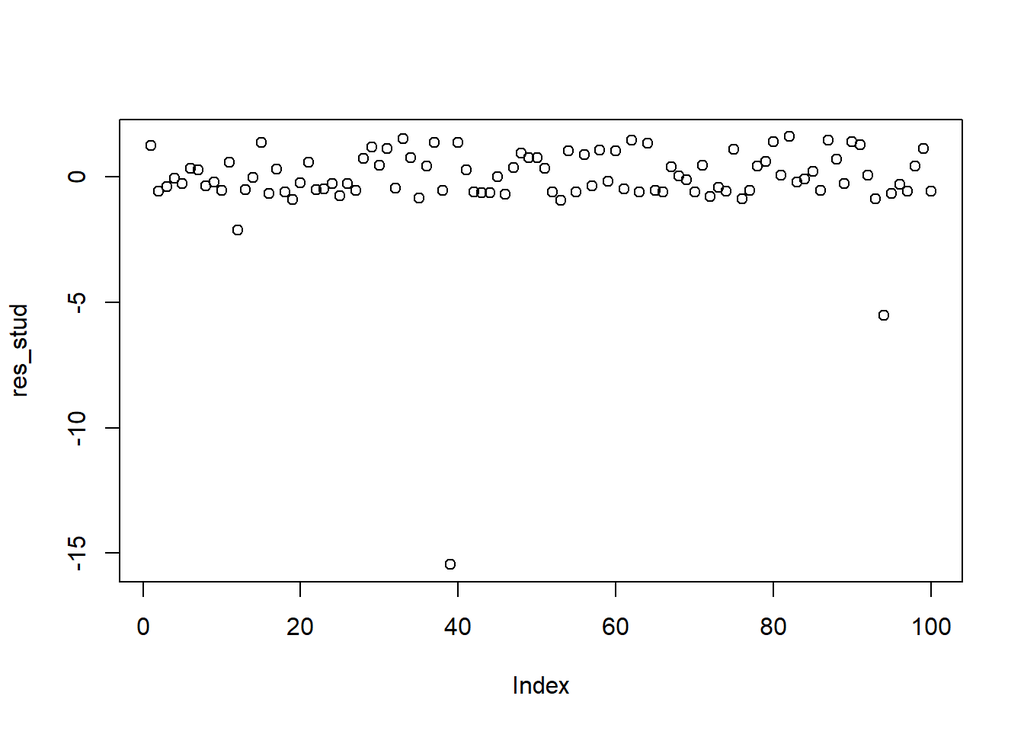

```r
y.hat<-modelo$fitted.values
res_stud<-rstudent(modelo)
res_pad<-rstandard(modelo)
plot(res_stud)
```

#### Normalidade

**Código**

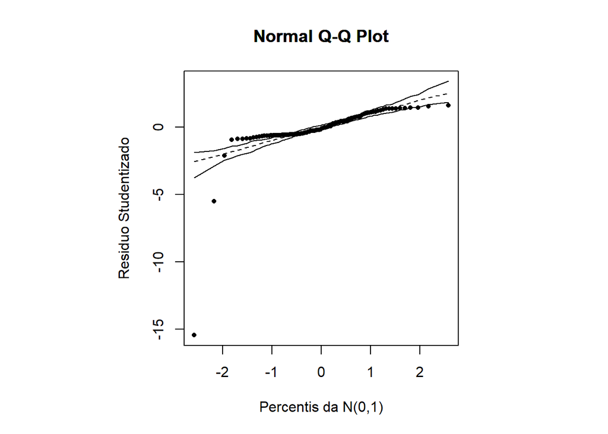

```r
envel_norm(modelo)
```

#### Homodedasticidade

**Código**

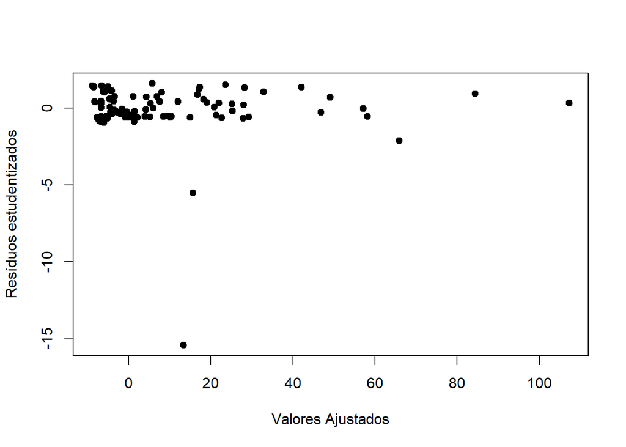

```r
plot(y.hat,res_stud,xlab="Valores Ajustados", ylab="Resíduos estudentizados",pch=19)
```

Os resíduos não parecem ter variância constante.

#### Resíduo x variável explicativa

**Código**

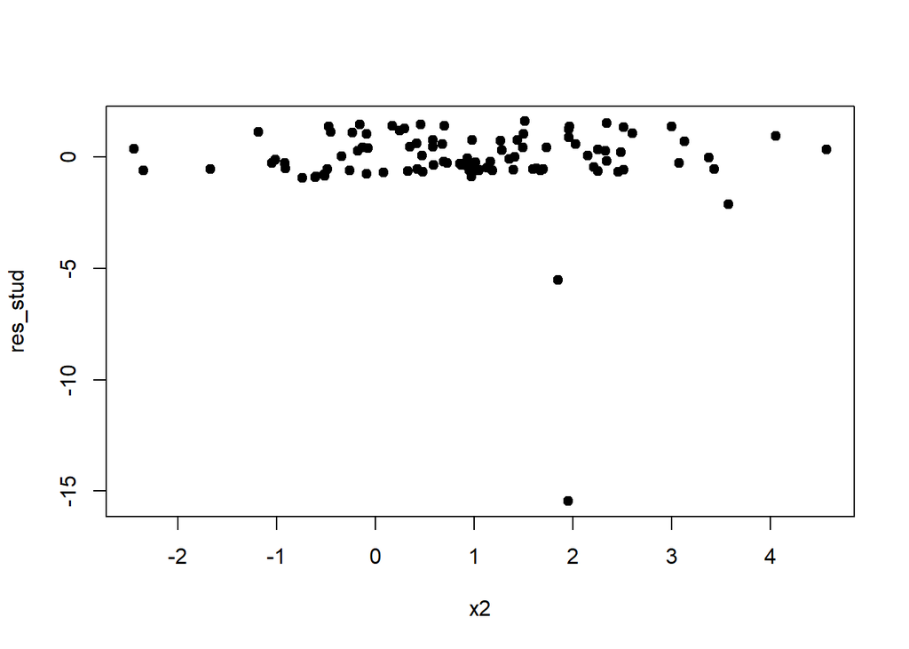

```r
plot(x2, res_stud, pch=19)
```

**Código**

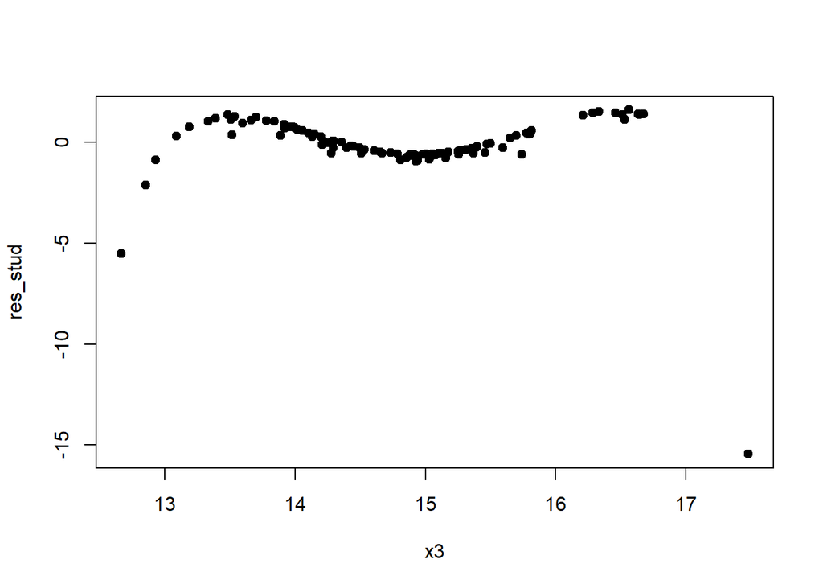

```r
plot(x3, res_stud, pch=19)
```

Não consegui chegar em um modelo validado adicionando mais termos das variáveis explicativas. Talvez seja necessário aplicar outra metodologia.